# Principal Component Analysis

Data Mining

Description for Principal Component Analysis

Yeongeun Jeon , Jung In Seo  
2023-09-02

- **참고**
  - **R을 활용한 다변량 자료분석 방법론, 강현철 $\cdot$ 연규필 $\cdot$ 한상태 저**
  - **Machine Learning with R, the tidyverse, and mlr, Hefin I. Rhys 저**

> Principal Component Analysis의 장점
- Principal Component Analysis에서 생성된 새 축은 Original 변수들 측면에서 직접 해석할 수 있다.
- 새로운 데이터셋을 주축에 투영할 수 있다.
  - 새로운 값을 주성분에 대입하여 수학적으로 차원 축소된 값을 얻을 수 있다.
- Principal Component Analysis는 수학적 변환이므로 계산적인 부담이 적다.

> Principal Component Analysis의 단점
- 주성분은 선형결합식으로 이루어져 있으며, 비선형으로 차원 축소가 불가능하다.
- 수치형 변수만 적용할 수 있다.
- 주성분의 개수는 여러가지 지표를 이용하여 사용자가 판단해야 한다.

# **Package Loading**

```r
pacman::p_load("data.table",
               "tidyverse",
               "dplyr", "psych",
               "ggplot2", "GGally",
               "factoextra",
               "ggbiplot")

# pacman::p_load("devtools")
# install_github("vqv/ggbiplot")
# library(ggbiplot)
```

# **예제 1**

- 주성분분석을 수행하기 위해 사용되는 데이터는 [자유아카데미](http://www.freeaca.com/new/library/BoardFileList.aspx?page=1&sword=%eb%8b%a4%eb%b3%80%eb%9f%89&stype=title&area=2)에서 출판한 책 **R을 활용한 다변량 자료분석 방법론**의 데이터 파일 중 “satis.csv”이다.
- 이 데이터는 어떤 제품에 대한 고객의 만족도를 조사하여 얻어진 데이터로 총 8개의 변수를 포함한다.
  1. `ID` : 고객 아이디
  2. `gender` : 고객 성별
  3. `age` : 고객 나이
  4. `x1` : 가격에 대한 만족도
  5. `x2` : 성능에 대한 만족도
  6. `x3` : 편리성에 대한 만족도
  7. `x4` : 디자인에 대한 만족도
  8. `x5` : 색상에 대한 만족도
- 만족도는 5점 척도로 측정되어 있으며, “1 = 매우 만족하지 않는다.”, “2 = 만족하지 않는다.”, “3 = 보통이다.”, “4 = 만족한다.”, “5 = 매우 만족한다.”를 의미한다.

## **1. 데이터 불러오기**

```r
satis <- read.csv("satis.csv")
satis
```

```
   ID gender age x1 x2 x3 x4 x5
1   1      F  10  1  2  4  1  1
2   2      F  10  1  2  3  2  1
3   3      F  20  2  5  5  2  2
4   4      F  20  2  5  4  2  2
5   5      F  30  1  2  3  4  3
6   6      M  30  1  3  4  1  1
7   7      M  40  4  5  5  3  3
8   8      M  40  1  3  4  4  4
9   9      M  50  3  3  5  5  4
10 10      M  50  5  5  5  4  4
```

## **2. 데이터 탐색**

### **2-1. 기술통계량**

```r
describe(satis[,c("x1", "x2", "x3", "x4", "x5")])
```

```
   vars  n mean   sd median trimmed  mad min max range  skew kurtosis
x1    1 10  2.1 1.45    1.5    1.88 0.74   1   5     4  0.83    -0.92
x2    2 10  3.5 1.35    3.0    3.50 1.48   2   5     3  0.12    -1.94
x3    3 10  4.2 0.79    4.0    4.25 1.48   3   5     2 -0.29    -1.50
x4    4 10  2.8 1.40    2.5    2.75 2.22   1   5     4  0.10    -1.64
x5    5 10  2.5 1.27    2.5    2.50 2.22   1   4     3  0.00    -1.82
     se
x1 0.46
x2 0.43
x3 0.25
x4 0.44
x5 0.40
```

`Caution!` Package `"psych"`에서 제공하는 함수 `describe()`를 이용하여 기술통계량을 출력할 수 있다.  
`Result!` 변수 `x1`의 표준편차는 다른 변수들에 비해 상대적으로 큰 반면, 변수 `x3`는 다른 변수들에 비해 상대적으로 표준편차가 작다.

### **2-2. 상관행렬**

```r
cor(satis[,c("x1", "x2", "x3", "x4", "x5")])
```

```
          x1         x2        x3         x4        x5
x1 1.0000000 0.70784332 0.7581754 0.44960032 0.5738636
x2 0.7078433 1.00000000 0.7282191 0.05868157 0.2909287
x3 0.7581754 0.72821908 1.0000000 0.24174689 0.4438968
x4 0.4496003 0.05868157 0.2417469 1.00000000 0.9389683
x5 0.5738636 0.29092868 0.4438968 0.93896829 1.0000000
```

`Result!` 상대적으로 표준편차가 큰 변수 `x1`는 다른 변수들과 상관관계가 강하며, 특히, 변수 `x3`와 강한 양의 상관성을 가지고 있다($r=0.758$). 그리고, 변수`x4`와 `x5`도 매우 강한 양의 상관성을 가지고 있다($r=0.939$).

### **2-3. 산점도행렬**

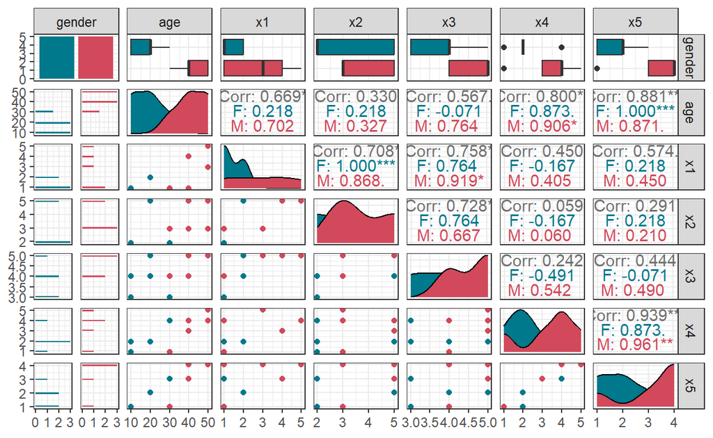

```r
ggpairs(satis[,-1],
        mapping = aes(col = gender), alpha = 0.8) +         # 변수 gender의 범주에 따라 색깔을 다르게 표현
    scale_colour_manual(values = c("#00798c", "#d1495b")) + # 특정 색깔 지정
  scale_fill_manual(values = c("#00798c", "#d1495b")) +     # 특정 색깔 지정
  theme_bw()
```

## **3. 공분산행렬을 이용한 주성분분석**

```r
satis.prcomp <- prcomp(satis[,c("x1", "x2", "x3", "x4", "x5")])
satis.prcomp
```

```
Standard deviations (1, .., p=5):
[1] 2.2542944 1.5386966 0.6528647 0.4472292 0.2157445

Rotation (n x k) = (5 x 5):
         PC1        PC2         PC3        PC4        PC5
x1 0.5723794  0.2916057 -0.72250071  0.2316137  0.1081469
x2 0.3966884  0.6003640  0.62118712  0.2716472 -0.1501190
x3 0.2564469  0.2233868 -0.03232539 -0.9143660 -0.2173088
x4 0.4617789 -0.5982335  0.07138977  0.1323191 -0.6373947
x5 0.4858141 -0.3830720  0.29321981 -0.1378017  0.7157328
```

`Caution!` 주성분분석은 함수 `prcomp()`를 통해 수행할 수 있다. 자세한 옵션은 `?prcomp`를 통해 확인하거나 [여기](https://www.rdocumentation.org/packages/stats/versions/3.6.2/topics/prcomp)를 참고한다.  
`Result!` 함수 `prcomp()`는 5개의 결과를 리스트로 반환한다.

1. `sdev` : 데이터셋을 주성분에 투영했을 때의 표준편차인 주성분의 표준편차(= 공분산행렬의 고유값의 제곱근)
   - 출력 결과의 “Standard deviations”와 동일
2. `rotation` : 주축의 계수(= 공분산행렬의 단위 고유벡터)
   - 출력 결과의 “Rotation”과 동일
3. `center` : 변수의 평균
4. `scale` : 표준편차로 나누어 주는 작업 진행 여부
5. `x` : 주성분 점수

```r
satis.prcomp$sdev        # 주성분의 표준편차
```

```
[1] 2.2542944 1.5386966 0.6528647 0.4472292 0.2157445
```

```r
satis.prcomp$sdev^2      # 주성분의 분산 = 주성분에 의해 설명되는 분산의 양 = 공분산행렬의 고유값
```

```
[1] 5.08184308 2.36758724 0.42623226 0.20001396 0.04654569
```

`Caution!` 주성분의 분산은 함수 `eigen(cov(satis[,c("x1", "x2", "x3", "x4", "x5")]))`를 통해 얻어진 공분산행렬의 고유값과 동일하며, 공분산행렬의 대각성분 합이 주성분 분산의 합(공분산행렬의 고유값의 합)과 같음을 알 수 있다.

```r
satis.prcomp$rotation    # 주축의 계수
```

```
         PC1        PC2         PC3        PC4        PC5
x1 0.5723794  0.2916057 -0.72250071  0.2316137  0.1081469
x2 0.3966884  0.6003640  0.62118712  0.2716472 -0.1501190
x3 0.2564469  0.2233868 -0.03232539 -0.9143660 -0.2173088
x4 0.4617789 -0.5982335  0.07138977  0.1323191 -0.6373947
x5 0.4858141 -0.3830720  0.29321981 -0.1378017  0.7157328
```

`Caution!` 주축의 계수는 함수 `eigen(cov(satis[,c("x1", "x2", "x3", "x4", "x5")]))`를 통해 얻어진 공분산행렬의 단위 고유벡터와 동일하다.  
`Result!` 첫 번째 주성분은 $Y_1=0.572C_{1}+0.397C_{2}+0.256C_{3}+0.462C_{4}+0.486C_5$이며, 두 번째 주성분은 $Y_2=0.292C_1+0.600C_2+0.223C_3-0.598C_4-0.383C_5$이다. 여기서 확률변수 $C_{i}$는 $X_i-\mu_i$이며, $\mu_i$는 $X_i$의 평균을 의미한다. 또한, 변수 `x1`-`x5`는 $X_1$-$X_5$로 표현한다.  
주성분의 의미를 해석해보면, 첫 번째 주성분은 계수가 서로 비슷하므로 전반적인 만족도를 나타낸다고 할 수 있으며, 두 번째 주성분은 변수 `x1-x3`와 변수 `x4-x5`의 부호가 반대이므로 가격, 성능, 편리성 제품의 “내형적 요인”과 디자인, 색상 등 제품의 “외형적 요인”의 만족도 차이를 나타낸다고 할 수 있다.

```r
# 요약
summary(satis.prcomp)
```

```
Importance of components:
                          PC1    PC2     PC3     PC4     PC5
Standard deviation     2.2543 1.5387 0.65286 0.44723 0.21574
Proportion of Variance 0.6257 0.2915 0.05248 0.02463 0.00573
Cumulative Proportion  0.6257 0.9172 0.96964 0.99427 1.00000
```

`Result!` 처음 2개의 고유값은 5.082(= $2.2543^2$), 2.368(= $1.5387^2$)로서 각각 전체 변동의 62.6%(= 5.082/8.122)와 29.2%(= 2.368/8.122)를 차지한다. 따라서, 처음 2개의 주성분에 의해 데이터 변동의 약 91.7%가 설명될 수 있음을 알 수 있다. 이는 2개의 주성분만으로 데이터 변동을 충분히 설명할 수 있음을 의미한다. 만약 처음 2개의 주성분을 새로운 변수로 고려할 경우, 이는 원래 다섯 개의 예측변수들이 가지고 있는 정보를 2차원으로 축소한다는 의미이다.

```r
# 변수 적재 Ver.1
1:5 %>%                                              # 첫 번째 변수부터 다섯 번째 변수에 function을 적용
  map_df(function(x) satis.prcomp$rotation[,x]*satis.prcomp$sdev[x])
```

```
# A tibble: 5 × 5
       x1      x2      x3      x4      x5
    <dbl>   <dbl>   <dbl>   <dbl>   <dbl>
1  1.29    0.894   0.578   1.04    1.10
2  0.449   0.924   0.344  -0.920  -0.589
3 -0.472   0.406  -0.0211  0.0466  0.191
4  0.104   0.121  -0.409   0.0592 -0.0616
5  0.0233 -0.0324 -0.0469 -0.138   0.154
```

`Caution!` 주성분의 변수 적재(Variable Loading)는 단위 고유벡터(= 주축의 계수)와 고유값의 제곱근(= 주성분의 표준편차)을 곱함으로써 계산될 수 있다. 변수 적재를 계산하기 위해 함수 `map_df()`를 이용한다.  
`Result!` 변수 적재는 각 변수가 특정 주성분에 얼마나 기여하는지를 설명한다. 결과값의 부호는 양/음의 상관관계를 나타내며, 값의 절대값이 클수록 주성분과 변수는 강한 관계를 가지고 있다. 출력 결과는 주성분과 변수 사이의 공분산처럼 해석할 수 있다. 예를 들어, 변수 `x1`은 첫 번째 주성분과 양의 상관성(1.29)을 가지고 있으며, 변수 `x4`는 두 번째 주성분과 음의 상관성(-0.920)을 가지고 있다.

```r
# 변수 적재 Ver.2
pcaDat <- get_pca(satis.prcomp)                      # 주성분 결과에서 변수에 대한 정보(좌표, 제곱 코사인, 기여) 추출
round(pcaDat$coord,3)                                # 변수 적재
```

```
   Dim.1  Dim.2  Dim.3  Dim.4  Dim.5
x1 1.290  0.449 -0.472  0.104  0.023
x2 0.894  0.924  0.406  0.121 -0.032
x3 0.578  0.344 -0.021 -0.409 -0.047
x4 1.041 -0.920  0.047  0.059 -0.138
x5 1.095 -0.589  0.191 -0.062  0.154
```

`Caution!` 변수 적재는 package `"factoextra"`에서 제공하는 함수 `get_pca()`를 이용하여 계산할 수 있다.

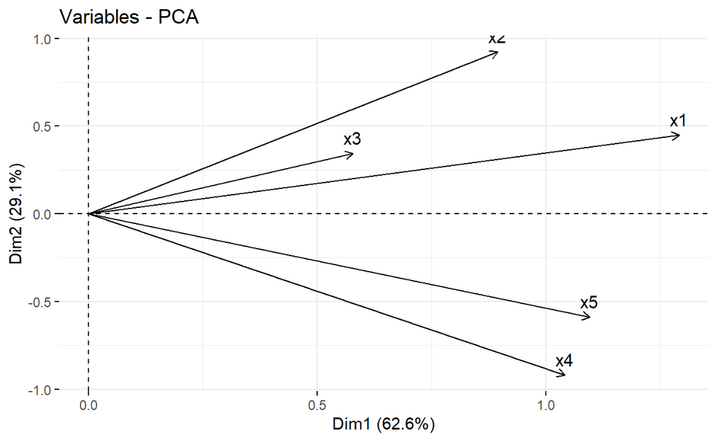

```r
# 변수 적재 그래프
fviz_pca_var(satis.prcomp)
```

`Caution!` 변수 적재 그래프는 package `"factoextra"`에서 제공하는 함수 `fviz_pca_var()`를 이용하여 만들 수 있다.  
`Result!` 그래프의 x축과 y축은 각각 첫 번째 주성분과 두 번째 주성분에 대한 변수 적재값을 의미하며, 특정 주축을 기준으로 화살표의 길이가 길수록 해당 변수와 해당 주성분은 강한 상관성을 가진다.

```r
# 주성분 점수
satis.score <- satis.prcomp$x
satis.score
```

```
             PC1        PC2         PC3         PC4         PC5
 [1,] -2.8358625  0.3854386 -0.69889614 -0.51084444  0.22339007
 [2,] -2.6305305 -0.4361818 -0.59518098  0.53584068 -0.19669584
 [3,]  0.1306219  1.7202178  0.77444872 -0.38413777 -0.25779081
 [4,] -0.1258250  1.4968309  0.80677411  0.53022827 -0.04048198
 [5,] -0.7353444 -2.3987927  0.13403819  0.52487542 -0.04001978
 [6,] -2.4391741  0.9858026 -0.07770902 -0.23919722  0.07327109
 [7,]  2.2229738  1.3221236 -0.30594311  0.07360693  0.03684093
 [8,]  0.4036049 -1.9581138  1.01611974 -0.25564510  0.30828518
 [9,]  2.2665896 -1.7497491 -0.38981729 -0.57446472 -0.33012467
[10,]  3.7429463  0.6324238 -0.66383422  0.29973796  0.22332582
```

`Caution!` 주성분 점수는 각 case의 관측값을 주성분에 대입함으로써 얻을 수 있으며, 고차원의 원본 데이터셋 대신 차원이 축소된 데이터셋으로 유용하게 사용될 수 있다. 함수 `prcomp()`를 이용한 결과 `satis.prcomp`에는 주성분 점수가 포함되어 있다.
`Result!` 첫 번째 주성분과 두 번째 주성분에 의해 얻어지는 $i$번째 case의 주성분 점수는 다음의 식을 이용하여 얻을 수 있다.
$$\begin{align}
\begin{cases}
y_{i1}=0.572c_{i1}+0.397c_{i2}+0.256c_{i3}+0.462c_{i4}+0.486c_{i5},\\
y_{i2}=0.292c_{i1}+0.600c_{i2}+0.223c_{i3}-0.598c_{i4}-0.383c_{i5},
\end{cases}
\end{align}$$
여기서 $c_{ij}=x_{ij}-\bar{x}_{j}$는 $i$번째 case의 $j$번째 변수 관찰값 $x_{ij}$에서 $j$번째 변수의 평균값 $\bar{x}_j$을 뺀 것을 의미한다.

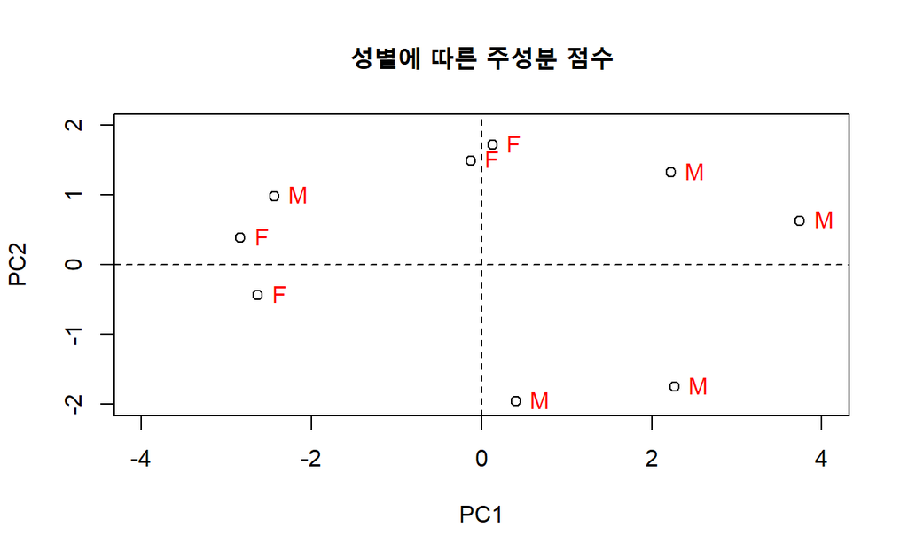

```r
# 성별에 따른 주성분 점수 그래프 Ver.1
plot(satis.score[,1:2],                              # 첫 번째와 두 번째 주성분 점수
     xlim = c(-4, 4), ylim = c(-2, 2), main = "성별에 따른 주성분 점수")
abline(v = 0, h = 0, lty = 2)
text(satis.score[,1:2],  labels = satis$gender, pos = 4, col = "red")
```

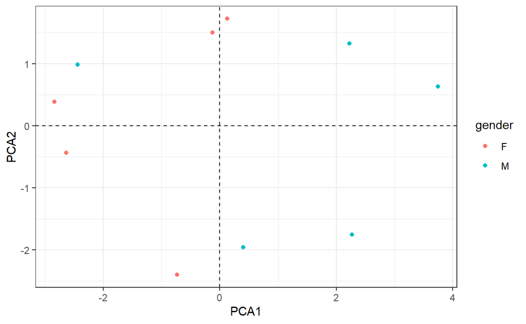

```r
# 성별에 따른 주성분 점수 그래프 Ver.2
satisPca <- satis %>%
  mutate(PCA1 = satis.score[, 1], PCA2 = satis.score[, 2])

ggplot(satisPca, aes(PCA1, PCA2,
                     col = gender)) +                # 변수 gender의 범주에 따라 색깔을 다르게 표현
  geom_point() +
  geom_hline(yintercept=0, linetype='dashed', color='black') +
  geom_vline(xintercept=0, linetype='dashed', color='black') +
  theme_bw()
```

`Result!` 그래프의 수직선을 중심으로 오른쪽에 위치하는 점들은 첫 번째 주성분 점수가 높다는 것을 의미하고 왼쪽에 위치하는 점들은 첫 번째 주성분 점수가 낮다는 것을 의미한다. 오른쪽에 위치하는 점 5개 중 4개가 남자이므로, 전반적으로 남자가 여자보다 첫 번째 주성분 점수가 높으며, 이는 남자들의 전반적인 만족도가 높다고 해석할 수 있다. 마찬가지로 수평선을 중심으로 위쪽에 위치하는 점들은 두 번째 주성분 점수가 높다는 것을 의미하고 아래쪽에 위치하는 점들은 두 번째 주성분 점수가 낮다는 것을 의미한다. 두 번째 주성분 점수가 높다는 것은 가격, 성능, 편리성 등 제품의 내형적 요인에 대해서는 만족도가 높으나 디자인, 색상 등 외형적 요인에 대해서는 만족도가 낮다고 해석할 수 있다.

```r
# 주성분 점수 예측
predict(satis.prcomp, newdata = tail(satis[,c("x1", "x2", "x3", "x4", "x5")], 2))
```

```
        PC1        PC2        PC3        PC4        PC5
9  2.266590 -1.7497491 -0.3898173 -0.5744647 -0.3301247
10 3.742946  0.6324238 -0.6638342  0.2997380  0.2233258
```

`Caution!` 함수 `predict()`를 이용하여 새로운 case에 대한 주성분 점수를 예측할 수 있다. 여기서는 설명의 편의상 마지막 2개의 case를 새로운 자료로 취급하여 예측을 수행하였다.

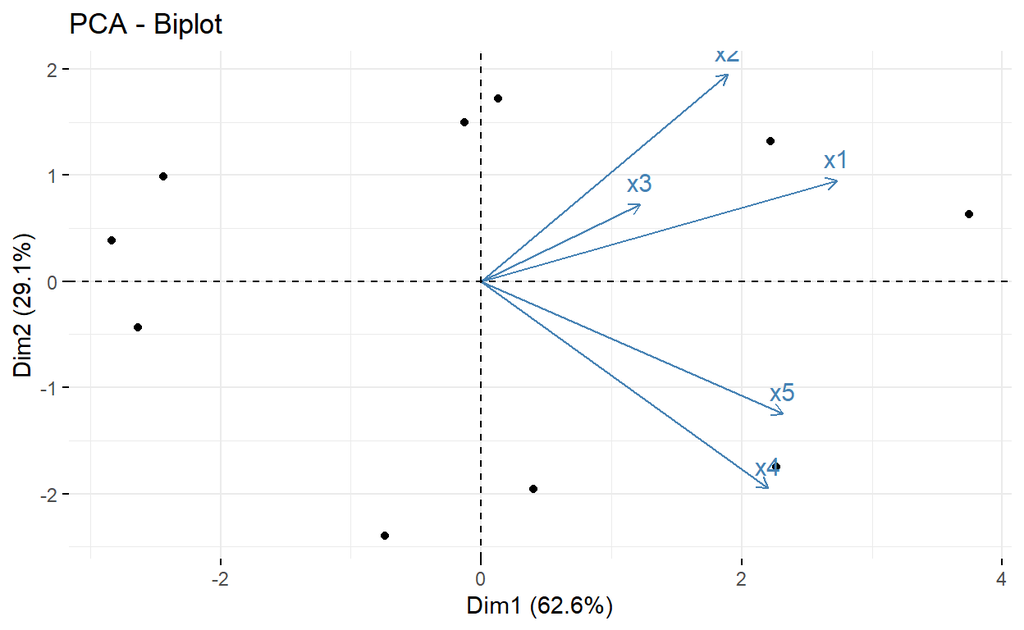

```r
# Biplot
fviz_pca_biplot(satis.prcomp, label = "var")
```

`Caution!` 주성분 점수와 변수 적재를 하나의 그래프에 함께 표현한 것을 행렬도(Biplot)라고 한다. 위 Biplot에서는 주성분 점수를 점으로 표현하고, 변수 적재를 화살표로 표현한다. Biplot는 다음을 기준으로 해석할 수 있다.  
1. 점은 각 case(= 데이터셋에서 하나의 행)에 대한 주성분 점수를 나타낸다.  
2. 화살표는 변수 적재값을 의미하며, 정확한 변수 적재값은 알 수 없다.  
3. 화살표의 길이는 상관성의 정도를 표현한다. 즉, 주축을 기준으로 화살표의 길이가 길수록 변수와 해당 주성분은 강한 상관성을 가진다.  
4. 화살표와 주축이 평행에 가까울수록 해당 변수는 해당 주성분에만 큰 영향을 미친다.  
5. 화살표들 간의 각도가 작을수록 해당 변수들은 강한 양의 상관관계를 나타내며, 180도는 강한 음의 상관관계를 나타낸다. 또한, 직각은 상관성이 없음을 의미한다.  
Biplot을 통해서 군집성, 변수들의 상관구조 등을 시각적으로 파악할 수 있다.  
`Result!` Biplot의 x축과 y축은 각각 첫 번째와 두 번째 주성분 점수를 의미한다. 변수 `x1`과 `x5`는 첫 번째 주축(x축, 수평 점선)을 기준으로 화살표의 길이가 길며 이는 두 변수가 첫 번째 주성분과 강한 상관성을 가진다고 할 수 있다. 또한, 변수 `x1`, `x2`, `x3`의 화살표들 간의 각도가 작기 때문에(즉, 서로 가까이 위치해있기 때문에) 강한 양의 상관관계를 가지며, 변수 `x4`와 `x5` 또한 강한 양의 상관관계를 가진다.

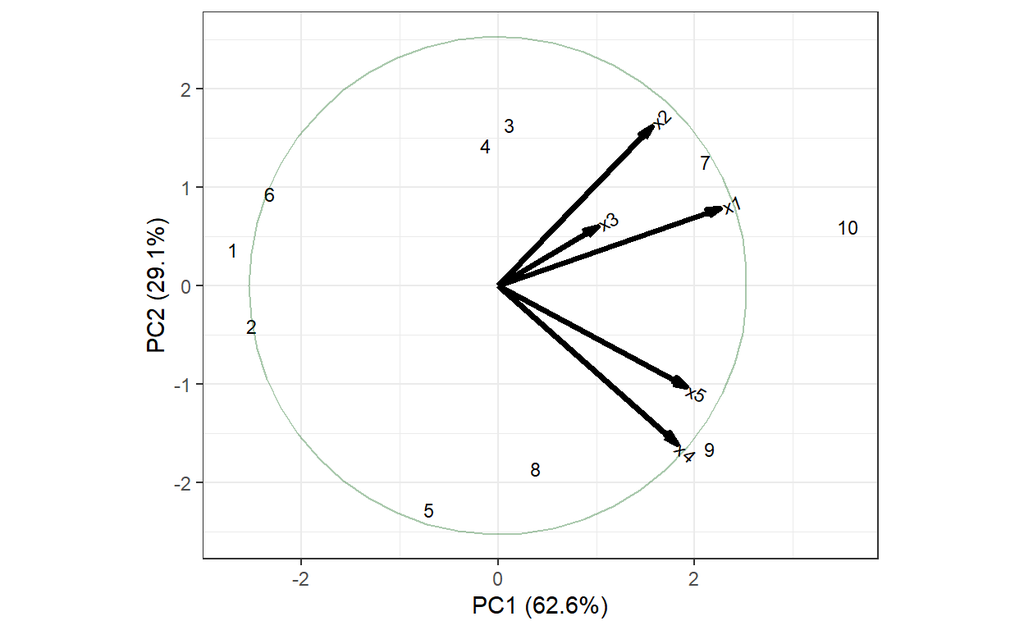

```r
# ggbiplot을 이용한 Biplot
ggbiplot(satis.prcomp,                      # 함수 prcomp에 의한 객체
         obs.scale = 1,                     # 관찰값에 적용할 scale
         var.scale = 1,                     # 변수에 적용할 scale
         labels = satis$ID,                 # 점에 대한 label
         circle = TRUE) +
  theme_bw()
```

`Caution!` Package `"ggbiplot"`에서 제공하는 함수 `ggbiplot()`를 이용하여 Biplot을 만들 수 있으며, 함수에 대한 자세한 옵션은 [여기](https://www.rdocumentation.org/packages/ggbiplot/versions/0.55/topics/ggbiplot)를 참고한다.

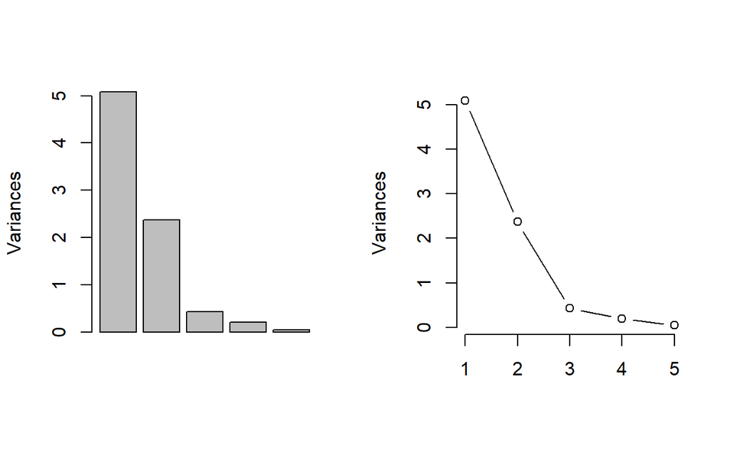

```r
# 스크리 그래프 Ver.1 (y축 : 고유값)
par(mfrow = c(1, 2))
screeplot(satis.prcomp, type = "b", main = "")  # 막대 그래프
screeplot(satis.prcomp, type = "l", main = "")  # 선 그래프
```

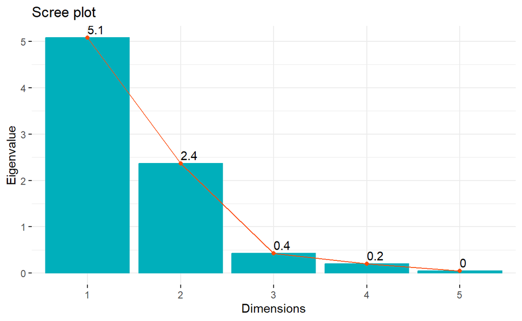

```r
# 스크리 그래프 Ver.2
fviz_screeplot(satis.prcomp,
               addlabels = TRUE,                # 막대 높이 표시 여부
               # geom = "line",                 # 그래프 유형(bar / line)
               choice = "eigenvalue",           # y축 (variance / eigenvalue)
               linecolor = "#FC4E07",           # 선 색깔
               barcolor = "#00AFBB",            # 막대의 윤곽선 색깔
               barfill = "#00AFBB")             # 막대의 색깔
```

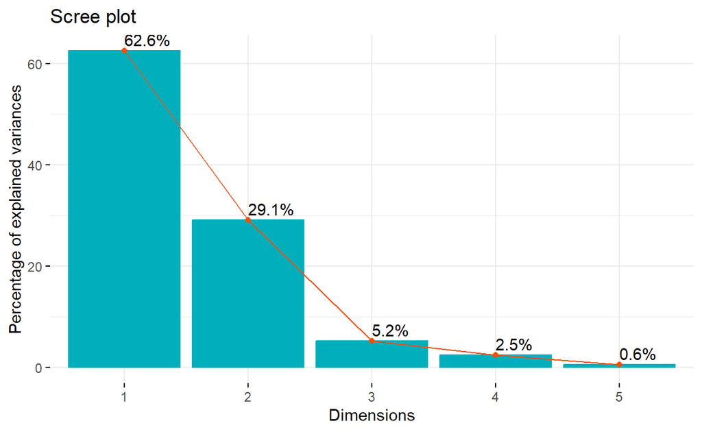

```r
fviz_screeplot(satis.prcomp,
               addlabels = TRUE,                # 막대 높이 표시 여부
               choice = "variance",             # y축(variance / eigenvalue)
               linecolor = "#FC4E07",           # 선 색깔
               barcolor = "#00AFBB",            # 막대의 윤곽선 색깔
               barfill = "#00AFBB")             # 막대의 색깔
```

`Result!` 스크리 그래프를 보면 첫 번째 주성분과 두 번째 주성분의 분산(고유값)이 크며 가파른 경사를 형성한다. 그러므로, 2개의 주성분 개수를 고려할 수 있다.

## **4. 상관행렬을 이용한 주성분분석**

```r
satis.cor.prcomp <- prcomp(satis[,c("x1", "x2", "x3", "x4", "x5")], center = TRUE, scale = TRUE)
satis.cor.prcomp
```

```
Standard deviations (1, .., p=5):
[1] 1.7628337 1.1829978 0.5033695 0.4610255 0.1643420

Rotation (n x k) = (5 x 5):
         PC1        PC2         PC3         PC4        PC5
x1 0.5106549  0.1714026 -0.05545212  0.83272782 -0.1155083
x2 0.4065628  0.5002084 -0.64671083 -0.37226185  0.1663863
x3 0.4650578  0.3439269  0.75415171 -0.29030512  0.1114166
x4 0.3795169 -0.6205430 -0.05742977 -0.01399615  0.6836660
x5 0.4621973 -0.4658899 -0.08153030 -0.28898535 -0.6922142
```

`Caution!` 상관행렬에 기초하여 주성분분석을 수행한다는 것은 표준화된 변수를 이용하여 주성분분석을 수행한다는 것을 의미한다. 함수 `prcomp()`의 옵션 `center = TRUE`와 `scale = TRUE`를 지정하여 변수를 표준화한 후, 상관행렬에 기초한 주성분분석을 수행할 수 있다.  
`Result!` 상관행렬을 이용한 주성분분석 결과는 위에서 공분산행렬에 기초하여 수행한 주성분분석 결과와는 다른 것을 확인할 수 있다.

```r
satis.cor.prcomp$sdev        # 주성분의 표준편차
```

```
[1] 1.7628337 1.1829978 0.5033695 0.4610255 0.1643420
```

```r
satis.cor.prcomp$sdev^2      # 주성분의 분산 = 주성분에 의해 설명되는 분산의 양 = 상관행렬의 고유값
```

```
[1] 3.1075826 1.3994838 0.2533809 0.2125445 0.0270083
```

`Caution!` 주성분의 분산은 함수 `eigen(cor(satis[,c("x1", "x2", "x3", "x4", "x5")]))`를 통해 얻어진 상관행렬의 고유값과 동일하며, 상관행렬의 대각성분 합이 주성분 분산의 합(상관행렬의 고유값의 합)인 변수 개수 “5”와 같음을 알 수 있다.

```r
satis.cor.prcomp$rotation    # 주축의 계수
```

```
         PC1        PC2         PC3         PC4        PC5
x1 0.5106549  0.1714026 -0.05545212  0.83272782 -0.1155083
x2 0.4065628  0.5002084 -0.64671083 -0.37226185  0.1663863
x3 0.4650578  0.3439269  0.75415171 -0.29030512  0.1114166
x4 0.3795169 -0.6205430 -0.05742977 -0.01399615  0.6836660
x5 0.4621973 -0.4658899 -0.08153030 -0.28898535 -0.6922142
```

`Caution!` 주축의 계수는 함수 `eigen(cor(satis[,c("x1", "x2", "x3", "x4", "x5")]))`를 통해 얻어진 상관행렬의 단위 고유벡터와 동일하다.  
`Result!` 첫 번째 주성분은 $Y_1=0.511Z_{1}+0.407Z_{2}+0.465Z_{3}+0.380Z_{4}+0.462Z_{5}$이며, 두 번째 주성분은 $Y_2=0.171Z_{1}+0.500Z_{2}+0.344Z_{3}-0.621Z_{4}-0.466Z_{5}$이 된다. 여기서 확률변수 $Z_{i}$는 $(X_i-\mu_i)/\sigma_{i}$이며, $\mu_i$와 $\sigma_{i}$는 각각 $X_i$의 평균과 표준편차를 의미한다. 또한, 변수 `x1`-`x5`는 $X_1$-$X_5$로 표현한다.  
주성분의 의미를 해석해보면, 첫 번째 주성분은 계수가 서로 비슷하므로 전반적인 만족도를 나타낸다고 할 수 있으며, 두 번째 주성분은 변수 `x1-x3`와 변수 `x4-x5`의 부호가 반대이므로 가격, 성능, 편리성 제품의 “내형적 요인”과 디자인, 색상 등 제품의 “외형적 요인”의 만족도 차이를 나타낸다고 할 수 있다.

```r
# 요약
summary(satis.cor.prcomp)
```

```
Importance of components:
                          PC1    PC2     PC3     PC4    PC5
Standard deviation     1.7628 1.1830 0.50337 0.46103 0.1643
Proportion of Variance 0.6215 0.2799 0.05068 0.04251 0.0054
Cumulative Proportion  0.6215 0.9014 0.95209 0.99460 1.0000
```

`Result!` 처음 2개의 고유값은 3.108(= $1.7628^2$), 1.399(= $1.1830^2$)로서 각각 전체 변동의 62.2%(= 3.108/5)와 28.0%(= 1.399/5)를 차지한다. 따라서, 처음 2개의 주성분에 의해 데이터 변동의 약 90.1%가 설명될 수 있음을 알 수 있다. 이는 2개의 주성분만으로 데이터 변동을 충분히 설명할 수 있음을 의미한다. 만약 처음 2개의 주성분을 새로운 변수로 고려할 경우, 이는 원래 다섯 개의 예측변수들이 가지고 있는 정보를 2차원으로 축소한다는 의미이다.

```r
# 변수 적재 Ver.1
1:5 %>%                                              # 첫 번째 변수부터 다섯 번째 변수에 function을 적용
  map_df(function(x) satis.cor.prcomp$rotation[,x]*satis.cor.prcomp$sdev[x])
```

```
# A tibble: 5 × 5
       x1      x2      x3       x4      x5
    <dbl>   <dbl>   <dbl>    <dbl>   <dbl>
1  0.900   0.717   0.820   0.669    0.815
2  0.203   0.592   0.407  -0.734   -0.551
3 -0.0279 -0.326   0.380  -0.0289  -0.0410
4  0.384  -0.172  -0.134  -0.00645 -0.133
5 -0.0190  0.0273  0.0183  0.112   -0.114
```

`Caution!` 주성분의 변수 적재(Variable Loading)는 단위 고유벡터(= 주축의 계수)와 고유값의 제곱근(= 주성분의 표준편차)을 곱함으로써 계산될 수 있다. 변수 적재를 계산하기 위해 함수 `map_df()`를 이용한다.  
`Result!` 변수 적재는 각 변수가 특정 주성분에 얼마나 기여하는지를 설명한다. 결과값의 부호는 양/음의 상관관계를 나타내며, 값의 절대값이 클수록 주성분과 변수는 강한 관계를 가지고 있다. 출력 결과는 피어슨 상관계수처럼 해석할 수 있다. 예를 들어, 변수 `x1`은 첫 번째 주성분과 강한 양의 상관성($r=0.900$)을 가지며, 변수 `x4`는 두 번째 주성분과 강한 음의 상관성($r=-0.734$)을 가진다.

```r
# 변수 적재 Ver.2
pcaDat <- get_pca(satis.cor.prcomp)                  # 주성분 결과에서 변수에 대한 정보(좌표, 제곱 코사인, 기여) 추출
round(pcaDat$coord,3)                                # 변수 적재
```

```
   Dim.1  Dim.2  Dim.3  Dim.4  Dim.5
x1 0.900  0.203 -0.028  0.384 -0.019
x2 0.717  0.592 -0.326 -0.172  0.027
x3 0.820  0.407  0.380 -0.134  0.018
x4 0.669 -0.734 -0.029 -0.006  0.112
x5 0.815 -0.551 -0.041 -0.133 -0.114
```

`Caution!` 변수 적재는 package `"factoextra"`에서 제공하는 함수 `get_pca()`를 이용하여 계산할 수 있다.

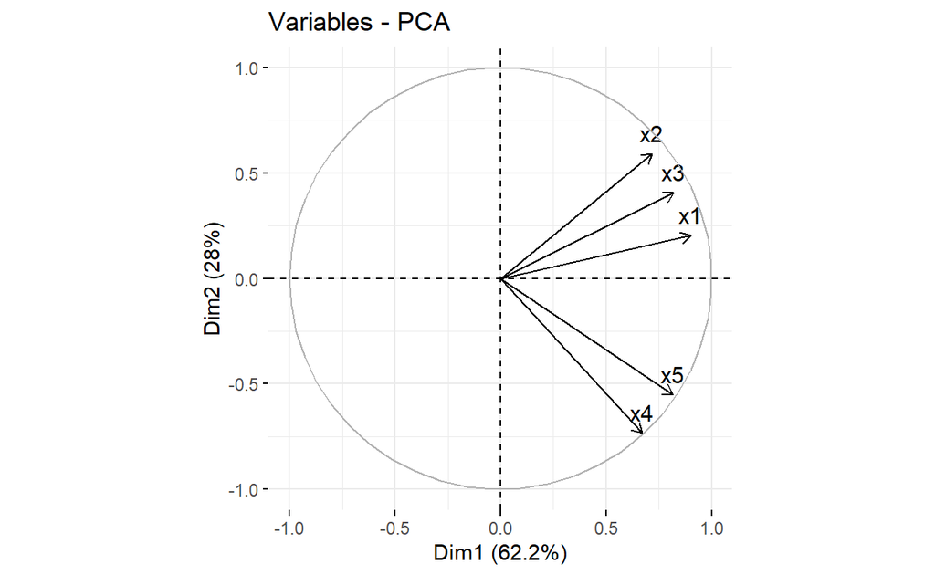

```r
# 변수 적재 그래프
fviz_pca_var(satis.cor.prcomp)
```

`Result!` 그래프의 x축과 y축은 각각 첫 번째 주성분과 두 번째 주성분에 대한 변수 적재값을 의미하며, 특정 주축을 기준으로 화살표의 길이가 길수록 해당 변수와 해당 주성분은 강한 상관성을 가진다.

```r
# 주성분 점수
satis.cor.score <- satis.cor.prcomp$x
satis.cor.score
```

```
             PC1        PC2         PC3          PC4         PC5
 [1,] -1.9906473  0.5778652  0.73759241  0.213431924 -0.18686461
 [2,] -2.3088242 -0.3018902 -0.25953723  0.571452234  0.16077659
 [3,]  0.4876344  1.4296420  0.11720524 -0.642443414  0.18686107
 [4,] -0.1019340  0.9936350 -0.83885655 -0.274414499  0.04561479
 [5,] -1.0377676 -1.9234789 -0.47013838  0.096087391  0.04784539
 [6,] -1.6903807  0.9472936  0.25996481 -0.061501673 -0.06398017
 [7,]  1.8279334  0.8554056 -0.06462653  0.269147743 -0.02902117
 [8,]  0.2162042 -1.4850896 -0.05593690 -0.774548937 -0.23337697
 [9,]  1.7819347 -1.2562730  0.78252584 -0.003312879  0.23734016
[10,]  2.8158471  0.1628903 -0.20819270  0.606102111 -0.16519509
```

`Caution!` 주성분 점수는 각 case의 관측값을 주성분에 대입함으로써 얻을 수 있으며, 고차원의 원본 데이터셋 대신 차원이 축소된 데이터셋으로 유용하게 사용될 수 있다. 함수 `prcomp()`를 이용한 결과 `satis.cor.prcomp`에는 주성분 점수가 포함되어 있다.
`Result!` 첫 번째 주성분과 두 번째 주성분에 의해 얻어지는 $i$번째 case의 주성분 점수는 다음의 식을 이용하여 얻을 수 있다.
$$\begin{align}
\begin{cases}
y_{i1}=0.511z_{i1}+0.407z_{i2}+0.465z_{i3}+0.380z_{i4}+0.462z_{i5},\\
y_{i2}=0.171z_{i1}+0.500z_{i2}+0.344z_{i3}-0.621z_{i4}-0.466z_{i5},
\end{cases}
\end{align}$$
여기서 $z_{ij}=(x_{ij}-\bar{x}_{j})/s_{j}$는 $i$번째 case의 $j$번째 변수 관찰값 $x_{ij}$에서 $j$번째 변수의 평균값 $\bar{x}_j$을 뺀 후 $j$번째 변수의 표준편차 값 $s_j$로 나눈 것을 의미한다.

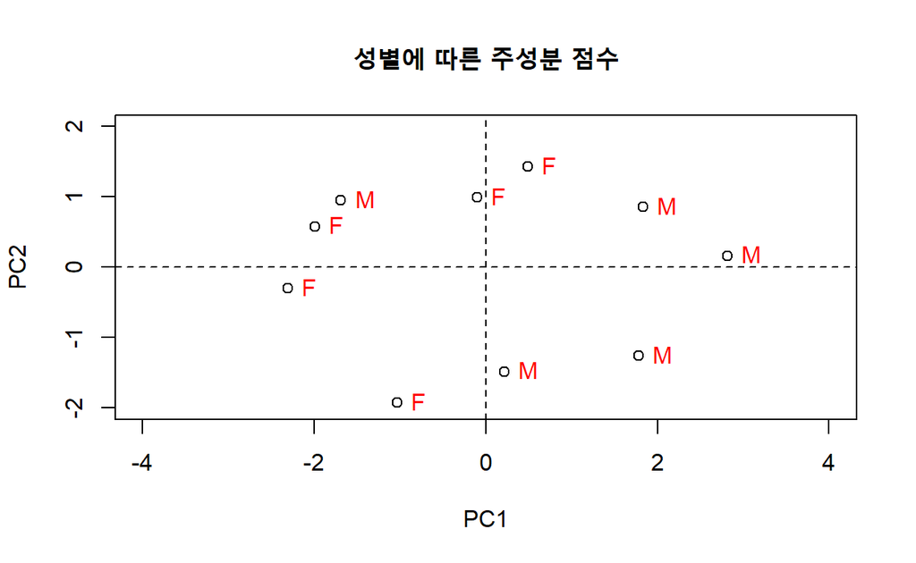

```r
# 성별에 따른 주성분 점수 그래프 Ver.1
plot(satis.cor.score[,1:2],                          # 첫 번째와 두 번째 주성분 점수
     xlim = c(-4, 4), ylim = c(-2, 2), main = "성별에 따른 주성분 점수")
abline(v = 0, h = 0, lty = 2)
text(satis.cor.score[,1:2],  labels = satis$gender, pos = 4, col = "red")
```

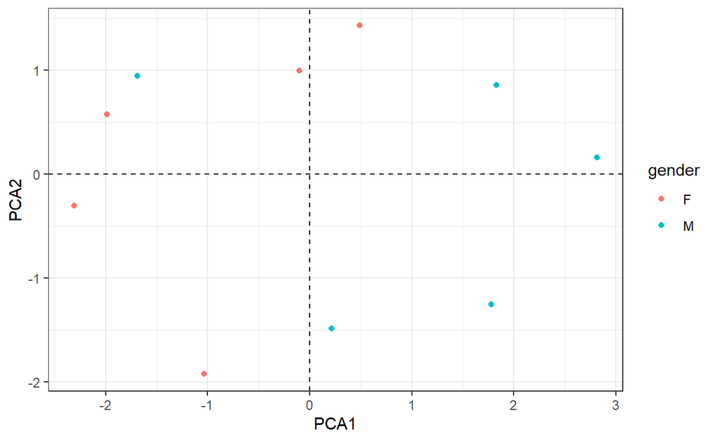

```r
# 성별에 따른 주성분 점수 그래프 Ver.2
satisPca <- satis %>%
  mutate(PCA1 = satis.cor.score[, 1], PCA2 = satis.cor.score[, 2])

ggplot(satisPca, aes(PCA1, PCA2,
                     col = gender)) +                # 변수 gender의 범주에 따라 색깔을 다르게 표현
  geom_point() +
  geom_hline(yintercept=0, linetype='dashed', color='black') +
  geom_vline(xintercept=0, linetype='dashed', color='black') +
  theme_bw()
```

`Result!` 그래프의 수직선을 중심으로 오른쪽에 위치하는 점들은 첫 번째 주성분 점수가 높다는 것을 의미하며, 왼쪽에 위치하는 점들은 첫 번째 주성분 점수가 낮다는 것을 의미한다. 오른쪽에 위치하는 점 5개 중 4개가 남자이므로, 이는 남자들의 전반적인 만족도가 높다고 해석할 수 있다. 마찬가지로 수평선을 중심으로 위쪽에 위치하는 점들은 두 번째 주성분 점수가 높다는 것을 의미하며, 아래쪽에 위치하는 점들은 두 번째 주성분 점수가 낮다는 것을 의미한다. 두 번째 주성분 점수가 높다는 것은 가격, 성능, 편리성 등 제품의 내형적 요인에 대해서는 만족도가 높으나 디자인, 색상 등 외형적 요인에 대해서는 만족도가 낮다고 해석할 수 있다.

```r
# 주성분 점수 예측
predict(satis.cor.prcomp, newdata = tail(satis[,c("x1", "x2", "x3", "x4", "x5")], 2))
```

```
        PC1        PC2        PC3          PC4        PC5
9  1.781935 -1.2562730  0.7825258 -0.003312879  0.2373402
10 2.815847  0.1628903 -0.2081927  0.606102111 -0.1651951
```

`Caution!` 함수 `predict()`를 이용하여 새로운 case에 대한 주성분 점수를 예측할 수 있다. 여기서는 설명의 편의상 마지막 2개의 case를 새로운 자료로 취급하여 예측을 수행하였다.

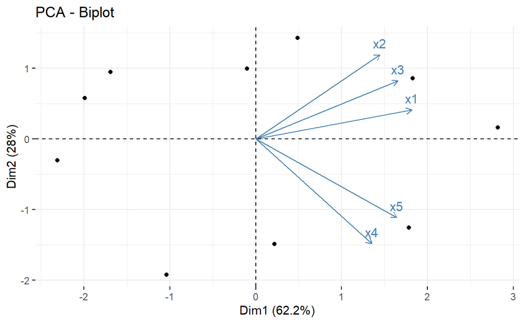

```r
# Biplot
fviz_pca_biplot(satis.cor.prcomp, label = "var")
```

`Caution!` 주성분 점수와 변수 적재를 하나의 그래프에 함께 표현한 것을 행렬도(Biplot)라고 한다. 위 Biplot에서는 주성분 점수를 점으로 표현하고, 변수 적재를 화살표로 표현한다. Biplot는 다음을 기준으로 해석할 수 있다.  
1. 점은 각 case(데이터셋에서 하나의 행)에 대한 주성분 점수를 나타낸다.  
2. 화살표는 변수 적재값을 의미하며, 정확한 변수 적재값은 알 수 없다.  
3. 화살표의 길이는 상관성의 정도를 표현한다. 즉, 주축을 기준으로 화살표의 길이가 길수록 변수와 해당 주성분은 강한 상관성을 가진다.  
4. 화살표와 주축이 평행에 가까울수록 해당 변수는 해당 주성분에만 큰 영향을 미친다.  
5. 화살표들 간의 각도가 작을수록 해당 변수들은 강한 양의 상관관계를 나타내며, 180도는 강한 음의 상관관계를 나타낸다. 또한, 직각은 상관성이 없음을 의미한다.  
Biplot을 통해서 군집성, 변수들의 상관구조 등을 시각적으로 파악할 수 있다.  
`Result!` Biplot의 x축과 y축은 각각 첫 번째와 두 번째 주성분 점수를 의미한다. 변수 `x1`과 `x5`는 첫 번째 주축(x축, 수평 점선)을 기준으로 화살표의 길이가 길며 이는 두 변수가 첫 번째 주성분과 강한 상관성을 가진다고 할 수 있다. 또한, 변수 `x1`, `x2`, `x3`의 화살표들 간의 각도가 작기 때문에(즉, 서로 가까이 위치해있기 때문에) 강한 양의 상관관계를 가지며, 변수 `x4`와 `x5` 또한 강한 양의 상관관계를 가진다.

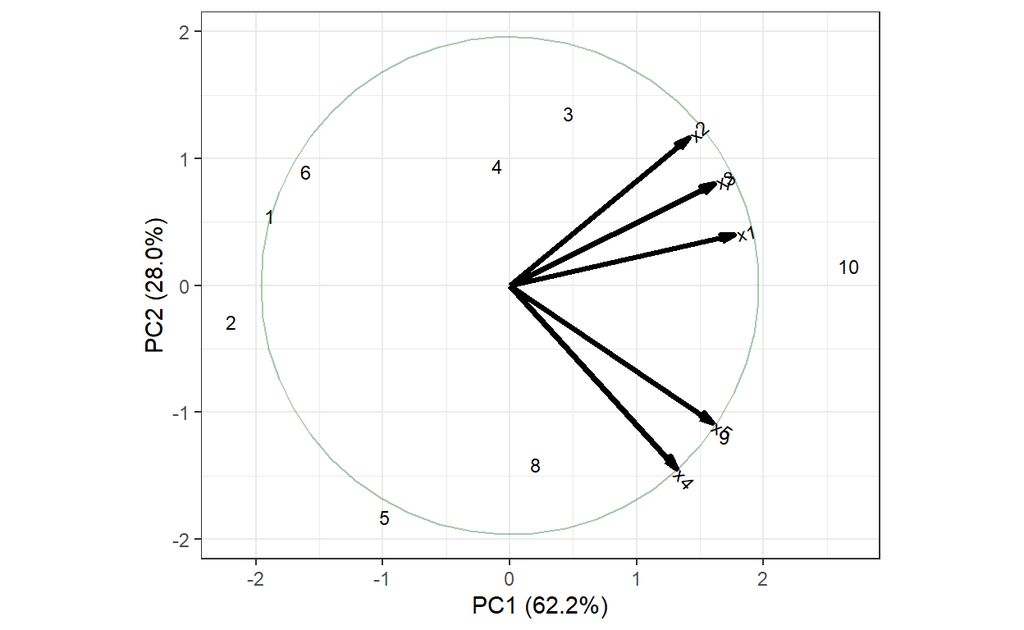

```r
# ggbiplot을 이용한 Biplot
ggbiplot(satis.cor.prcomp,                  # 함수 prcomp에 의한 객체
         obs.scale = 1,                     # 관찰값에 적용할 스케일
         var.scale = 1,                     # 변수에 적용할 스케일
         labels = satis$ID,                 # 점에 대한 라벨
         circle = TRUE) +
  theme_bw()
```

`Caution!` Package `"ggbiplot"`에서 제공하는 함수 `ggbiplot()`를 이용하여 Biplot을 만들 수 있으며, 함수에 대한 자세한 옵션은 [여기](https://www.rdocumentation.org/packages/ggbiplot/versions/0.55/topics/ggbiplot)를 참고한다.

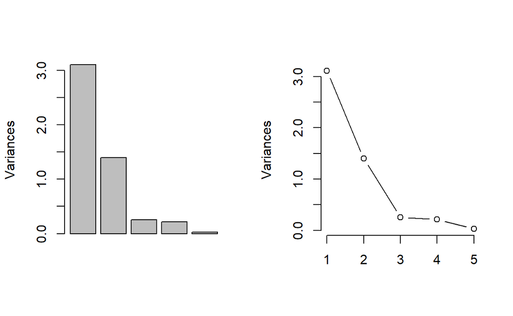

```r
# 스크리 그래프 Ver.1 (y축 : 고유값)
par(mfrow = c(1, 2))
screeplot(satis.cor.prcomp, type = "b", main = "")   # 막대그래프
screeplot(satis.cor.prcomp, type = "l", main = "")   # 선 그래프
```

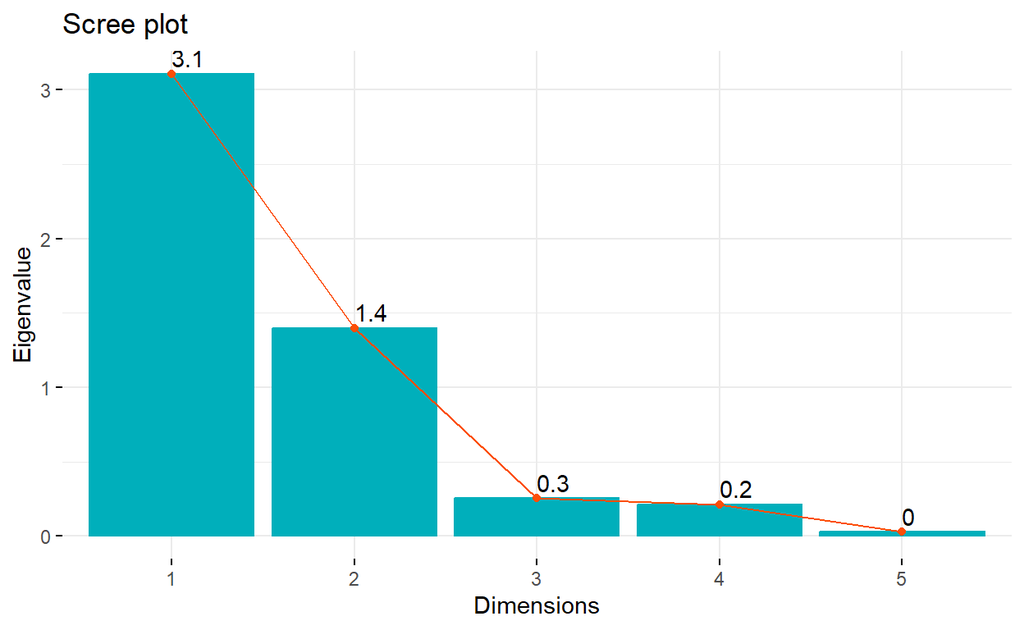

```r
# 스크리 그래프 Ver.2
fviz_screeplot(satis.cor.prcomp,
               addlabels = TRUE,                     # 막대 높이 표시 여부
               # geom = "line",                      # 그래프 유형(bar / line)
               choice = "eigenvalue",                # y축 (variance / eigenvalue)
               linecolor = "#FC4E07",                # 선 색깔
               barcolor = "#00AFBB",                 # 막대의 윤곽선 색깔
               barfill = "#00AFBB")                  # 막대의 색깔
```

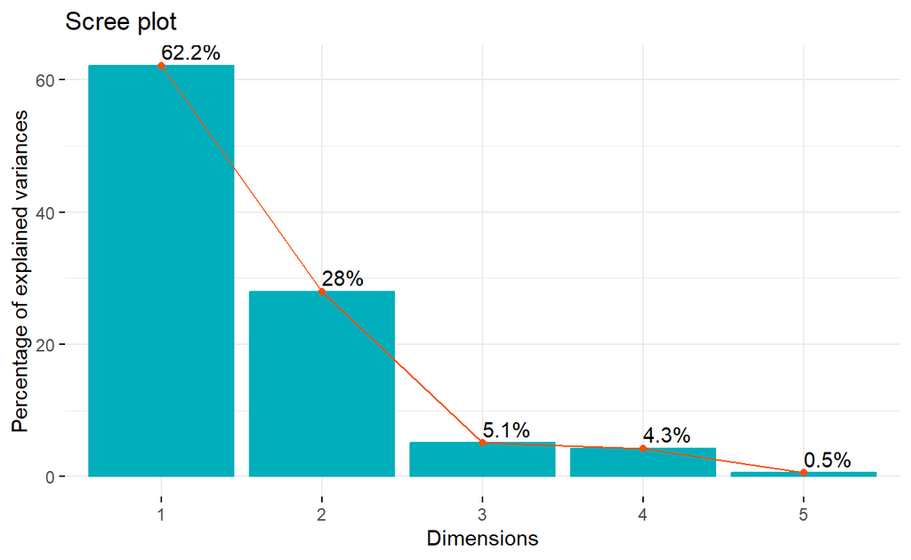

```r
fviz_screeplot(satis.cor.prcomp,
               addlabels = TRUE,                     # 막대 높이 표시 여부
               choice = "variance",                  # y축(variance / eigenvalue)
               linecolor = "#FC4E07",                # 선 색깔
               barcolor = "#00AFBB",                 # 막대의 윤곽선 색깔
               barfill = "#00AFBB")                  # 막대의 색깔
```

`Result!` 스크리 그래프를 보면, 첫 번째 주성분과 두 번째 주성분의 분산(고유값)이 크며 가파른 경사를 형성한다. 그러므로, 2개의 주성분 개수를 고려할 수 있다.

# **예제 2**

- 주성분분석을 수행하기 위해 사용되는 데이터는 [자유아카데미](http://www.freeaca.com/new/library/BoardFileList.aspx?page=1&sword=%eb%8b%a4%eb%b3%80%eb%9f%89&stype=title&area=2)에서 출판한 책 **R을 활용한 다변량 자료분석 방법론**의 데이터 파일 중 “student.csv”이다.
- 이 데이터는 10명의 학생에 대한 5과목 점수 데이터로 총 6개의 변수를 포함한다.
  1. `ID` : 학생 ID
  2. `x1` : 국어 점수
  3. `x2` : 영어 점수
  4. `x3` : 제2외국어 점수
  5. `x4` : 수학 점수
  6. `x5` : 과학 점수

## **1. 데이터 불러오기**

```r
student <- read.csv("student.csv")
student
```

```
   ID x1 x2 x3 x4 x5
1   1  3 33 73  8 12
2   2  3 30 59 28 20
3   3 35 83 91 32 34
4   4 35 83 85 33 32
5   5 15 40 55 68 52
6   6  3 53 76 10  8
7   7 68 83 85 48 50
8   8 15 47 77 76 76
9   9 46 60 83 83 68
10 10 98 83 91 80 72
```

## **2. 데이터 탐색**

### **2-1. 기술통계량**

```r
describe(student[,c("x1", "x2", "x3", "x4", "x5")])
```

```
   vars  n mean    sd median trimmed   mad min max range  skew
x1    1 10 32.1 31.56   25.0   27.50 31.88   3  98    95  0.80
x2    2 10 59.5 22.01   56.5   60.25 37.06  30  83    53 -0.02
x3    3 10 77.5 12.38   80.0   78.62  8.90  55  91    36 -0.63
x4    4 10 46.6 28.55   40.5   46.88 43.00   8  83    75  0.01
x5    5 10 42.4 24.94   42.0   42.50 35.58   8  76    68  0.00
   kurtosis   se
x1    -0.69 9.98
x2    -1.87 6.96
x3    -1.09 3.91
x4    -1.77 9.03
x5    -1.71 7.89
```

`Result!` 변수 `x1`의 표준편차는 다른 변수들에 비해 상대적으로 큰 반면, 변수 `x3`는 다른 변수들에 비해 상대적으로 표준편차가 작다.

### **2-2. 상관행렬**

```r
cor(student[,c("x1", "x2", "x3", "x4", "x5")])
```

```
          x1        x2        x3        x4        x5
x1 1.0000000 0.7838622 0.6833432 0.5592287 0.6102284
x2 0.7838622 1.0000000 0.8604151 0.2117815 0.3092596
x3 0.6833432 0.8604151 1.0000000 0.1380259 0.2793357
x4 0.5592287 0.2117815 0.1380259 1.0000000 0.9731614
x5 0.6102284 0.3092596 0.2793357 0.9731614 1.0000000
```

`Result!` 상대적으로 표준편차가 큰 변수 `x1`은 상대적으로 다른 변수들과 0.5 이상의 강한 상관성을 보인다. 그리고, 변수 `x4`와 `x5` 사이에는 매우 강한 양의 상관성을 가지고 있다($r=0.973$).

### **2-3. 산점도행렬**

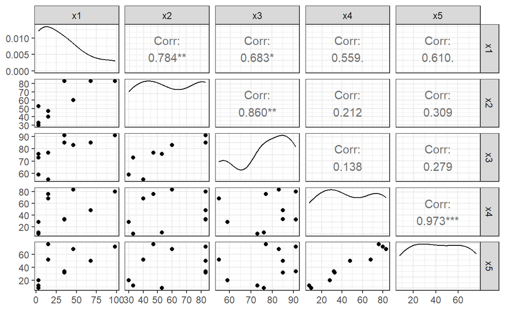

```r
ggpairs(student[,-1]) +
  theme_bw()
```

## **3. 공분산행렬을 이용한 주성분분석**

```r
student.prcomp <- prcomp(student[,c("x1", "x2", "x3", "x4", "x5")])
student.prcomp
```

```
Standard deviations (1, .., p=5):
[1] 46.259833 27.802085 10.689902  5.935039  2.997379

Rotation (n x k) = (5 x 5):
         PC1        PC2         PC3         PC4         PC5
x1 0.6155240  0.4184625  0.66098180 -0.08517714  0.04321101
x2 0.3149575  0.5395460 -0.57224849  0.52551269  0.07784525
x3 0.1533269  0.2865461 -0.39464213 -0.75500570 -0.41061682
x4 0.5208733 -0.5438504 -0.06785537  0.26119676 -0.60007473
x5 0.4765646 -0.3948383 -0.27438652 -0.27986409  0.68071806
```

`Caution!` 주성분분석은 함수 `prcomp()`를 통해 수행할 수 있다. 자세한 옵션은 `?prcomp`를 통해 확인하거나 [여기](https://www.rdocumentation.org/packages/stats/versions/3.6.2/topics/prcomp)를 참고한다.  
`Result!` 함수 `prcomp()`는 5개의 결과를 리스트로 반환한다.

1. `sdev` : 데이터셋을 주성분에 투영했을 때의 표준편차인 주성분의 표준편차(= 공분산행렬의 고유값의 제곱근)
   - 출력 결과의 “Standard deviations”와 동일
2. `rotation` : 주축의 계수(= 공분산행렬의 단위 고유벡터)
   - 출력 결과의 “Rotation”과 동일
3. `center` : 변수의 평균
4. `scale` : 표준편차로 나누어 주는 작업 진행 여부
5. `x` : 주성분 점수

```r
student.prcomp$sdev        # 주성분의 표준편차
```

```
[1] 46.259833 27.802085 10.689902  5.935039  2.997379
```

```r
student.prcomp$sdev^2      # 주성분의 분산 = 주성분에 의해 설명되는 분산의 양 = 공분산행렬의 고유값
```

```
[1] 2139.972189  772.955942  114.274008   35.224690    8.984282
```

`Caution!` 주성분의 분산은 함수 `eigen(cov(student[,c("x1", "x2", "x3", "x4", "x5")]))`를 통해 얻어진 공분산행렬의 고유값과 동일하며, 공분산행렬의 대각성분 합이 주성분 분산의 합(공분산행렬의 고유값의 합)과 같음을 알 수 있다.

```r
student.prcomp$rotation   # 주축의 계수
```

```
         PC1        PC2         PC3         PC4         PC5
x1 0.6155240  0.4184625  0.66098180 -0.08517714  0.04321101
x2 0.3149575  0.5395460 -0.57224849  0.52551269  0.07784525
x3 0.1533269  0.2865461 -0.39464213 -0.75500570 -0.41061682
x4 0.5208733 -0.5438504 -0.06785537  0.26119676 -0.60007473
x5 0.4765646 -0.3948383 -0.27438652 -0.27986409  0.68071806
```

`Caution!` 주축의 계수는 함수 `eigen(cov(student[,c("x1", "x2", "x3", "x4", "x5")]))`를 통해 얻어진 공분산행렬의 단위 고유벡터와 동일하다.  
`Result!` 첫 번째 주성분은 $Y_1=0.616C_{1}+0.315C_{2}+0.153C_{3}+0.521C_{4}+0.477C_{5}$이며, 두 번째 주성분은 $Y_2=0.418C_1+0.540C_2+0.287C_3-0.544C_4-0.395C_{5}$이 된다. 여기서 확률변수 $C_{i}$는 $X_i-\mu_i$이며, $\mu_i$는 $X_i$의 평균을 의미한다. 또한, 변수 `x1`-`x5`는 $X_1$-$X_5$로 표현한다.  
주성분의 의미를 해석해보면, 첫 번째 주성분은 계수가 서로 비슷하므로 전반적인 평점을 나타낸다고 할 수 있으며, 두 번째 주성분은 변수 `x1-x3`와 변수 `x4-x5`의 부호가 반대이므로 국어, 영어, 제2외국어의 “인문계열”과 수학, 과학의 “이과계열”의 점수 차이를 나타낸다고 할 수 있다.

```r
# 요약
summary(student.prcomp)
```

```
Importance of components:
                           PC1     PC2      PC3     PC4     PC5
Standard deviation     46.2598 27.8021 10.68990 5.93504 2.99738
Proportion of Variance  0.6967  0.2517  0.03721 0.01147 0.00293
Cumulative Proportion   0.6967  0.9484  0.98561 0.99707 1.00000
```

`Result!` 처음 2개의 고유값은 2139.972(= $46.2598^2$), 772.956(= $27.8021^2$)로서 각각 전체 변동의 69.7%(= 2139.972/3071.411)와 25.2%(= 772.956/3071.411)를 차지한다. 따라서, 처음 2개의 주성분에 의해 데이터 변동의 약 94.8%가 설명될 수 있음을 알 수 있다. 이는 2개의 주성분만으로 데이터 변동을 충분히 설명할 수 있음을 의미한다. 만약 처음 2개의 주성분을 새로운 변수로 고려할 경우, 이는 원래 다섯 개의 예측변수들이 가지고 있는 정보를 2차원으로 축소한다는 의미이다.

```r
# 변수 적재 Ver.1
1:5 %>%                                                # 첫 번째 변수부터 다섯 번째 변수에 function을 적용
  map_df(function(x) student.prcomp$rotation[,x]*student.prcomp$sdev[x])
```

```
# A tibble: 5 × 5
      x1     x2    x3      x4     x5
   <dbl>  <dbl> <dbl>   <dbl>  <dbl>
1 28.5   14.6    7.09  24.1    22.0
2 11.6   15.0    7.97 -15.1   -11.0
3  7.07  -6.12  -4.22  -0.725  -2.93
4 -0.506  3.12  -4.48   1.55   -1.66
5  0.130  0.233 -1.23  -1.80    2.04
```

`Caution!` 주성분의 변수 적재(Variable Loading)는 단위 고유벡터(= 주축의 계수)와 고유값의 제곱근(= 주성분의 표준편차)을 곱함으로써 계산될 수 있다. 변수 적재를 계산하기 위해 함수 `map_df()`를 이용한다.  
`Result!` 변수 적재는 각 변수가 특정 주성분에 얼마나 기여하는지를 설명한다. 결과값의 부호는 양/음의 상관관계를 나타내며, 값의 절대값이 클수록 주성분과 변수는 강한 관계를 가지고 있다. 출력 결과는 주성분과 변수 사이의 공분산처럼 해석할 수 있다. 예를 들어, 변수 `x1`은 첫 번째 주성분과 양의 상관성(28.5)을 가지고 있으며, 변수 `x4`는 두 번째 주성분과 음의 상관성(-15.1)을 가지고 있다.

```r
# 변수 적재 Ver.2
pcaDat <- get_pca(student.prcomp)                      # 주성분 결과에서 변수에 대한 정보(좌표, 제곱 코사인, 기여) 추출
round(pcaDat$coord,3)                                  # 변수 적재
```

```
    Dim.1   Dim.2  Dim.3  Dim.4  Dim.5
x1 28.474  11.634  7.066 -0.506  0.130
x2 14.570  15.001 -6.117  3.119  0.233
x3  7.093   7.967 -4.219 -4.481 -1.231
x4 24.096 -15.120 -0.725  1.550 -1.799
x5 22.046 -10.977 -2.933 -1.661  2.040
```

`Caution!` 변수 적재는 package `"factoextra"`에서 제공하는 함수 `get_pca()`를 이용하여 계산할 수 있다.

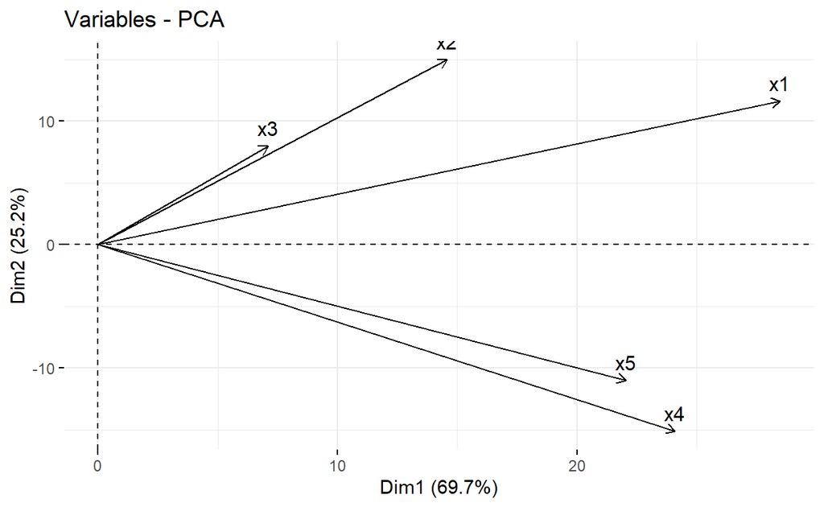

```r
# 변수 적재 그래프
fviz_pca_var(student.prcomp)
```

`Result!` 그래프의 x축과 y축은 각각 첫 번째 주성분과 두 번째 주성분에 대한 변수 적재값을 의미하며, 특정 주축을 기준으로 화살표의 길이가 길수록 해당 변수와 해당 주성분은 강한 상관성을 가진다.

```r
# 주성분 점수
student.score <- student.prcomp$x
student.score
```

```
              PC1        PC2        PC3        PC4         PC5
 [1,] -61.5413668   5.231022   8.666472 -9.6242324  0.99649177
 [2,] -50.4028345 -14.434976  12.356007  2.3543318 -0.04415861
 [3,]  -0.3514567  29.018103 -13.563126  0.4473432 -0.54559251
 [4,]  -1.7036742  27.544653 -10.714355  5.7983024 -0.04340246
 [5,]  -4.3952811 -39.552990   4.649289 11.0995753  0.67528203
 [6,] -55.6467471  17.373233  -3.000589  0.2628541 -2.60147547
 [7,]  34.9998806  26.089071   5.141256  1.8678545  4.63436503
 [8,]  16.7871502 -43.299075 -15.166696 -6.4591254  3.72326437
 [9,]  40.7164010 -22.241609  -2.763239 -2.7306959 -6.03517460
[10,]  81.5379285  14.272568  14.394982 -3.0162076 -0.75959955
```

`Caution!` 주성분 점수는 각 case의 관측값을 주성분에 대입함으로써 얻을 수 있으며, 고차원의 원본 데이터셋 대신 차원이 축소된 데이터셋으로 유용하게 사용될 수 있다. 함수 `prcomp()`를 이용한 결과 `student.prcomp`에는 주성분 점수가 포함되어 있다.
`Result!` 첫 번째 주성분과 두 번째 주성분에 의해 얻어지는 $i$번째 case의 주성분 점수는 다음의 식을 이용하여 얻을 수 있다.
$$\begin{align}
\begin{cases}
y_{i1}=0.616c_{i1}+0.315c_{i2}+0.153c_{i3}+0.521c_{i4}+0.477c_{i5},\\
y_{i2}=0.418c_{i1}+0.540c_{i2}+0.287c_{i3}-0.544c_{i4}-0.395c_{i5},
\end{cases}
\end{align}$$
여기서 $c_{ij}=x_{ij}-\bar{x}_{j}$는 $i$번째 case의 $j$번째 변수 관찰값 $x_{ij}$에서 $j$번째 변수의 평균값 $\bar{x}_j$을 뺀 것을 의미한다.

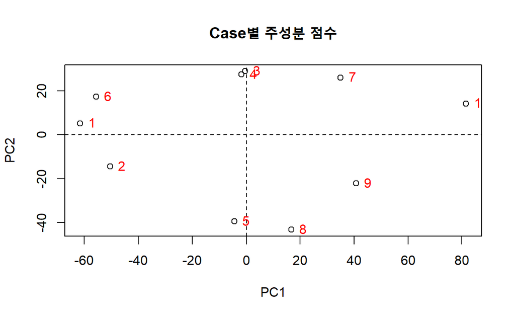

```r
# 주성분 점수 그래프 Ver.1
plot(student.score[,1:2],                              # 첫 번째와 두 번째 주성분 점수
     main = "Case별 주성분 점수")
abline(v = 0, h = 0, lty = 2)
text(student.score[,1:2],  labels = student$ID, pos = 4, col = "red")
```

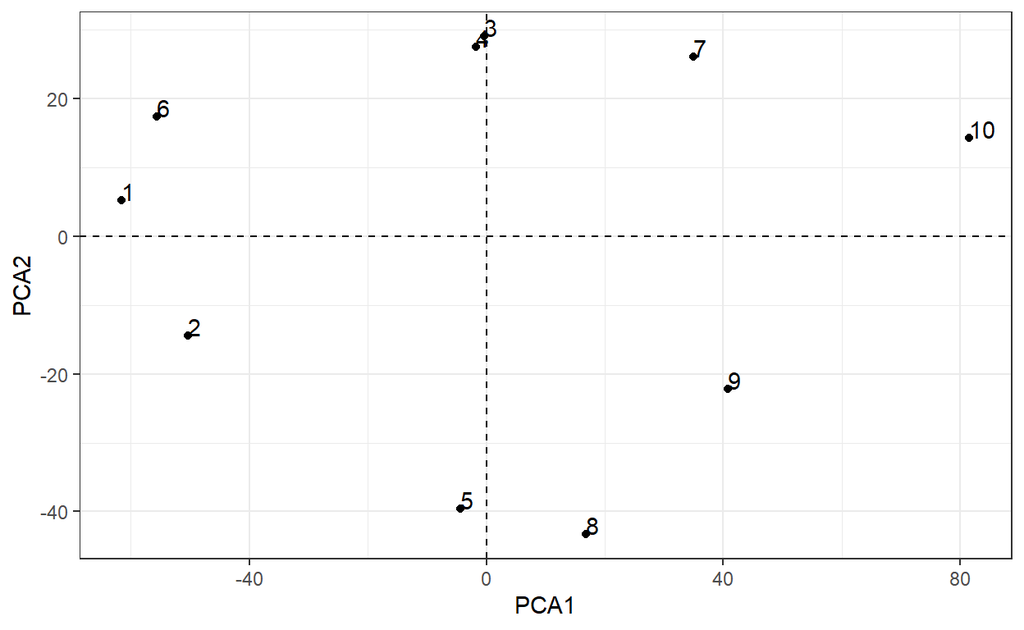

```r
# 주성분 점수 그래프 Ver.2
studentPca <- student %>%
  mutate(PCA1 = student.score[, 1], PCA2 = student.score[, 2])

ggplot(studentPca, aes(PCA1, PCA2)) +
  geom_point() +
  geom_hline(yintercept=0, linetype='dashed', color='black') +
  geom_vline(xintercept=0, linetype='dashed', color='black') +
  geom_text(aes(label = ID), hjust=0, vjust=0) +
  theme_bw()
```

`Result!` 그래프의 수직선을 중심으로 오른쪽에 위치하는 점들은 첫 번째 주성분 점수가 높다는 것을 의미하고 왼쪽에 위치하는 점들은 첫 번째 주성분 점수가 낮다는 것을 의미한다. 그래프를 살펴보면, 그래프의 오른쪽에 위치하는 “10”, “9”, “7”번 case는 첫 번째 주성분 값이 높으며, 이는 “10”, “9”, “7”번 case의 전반적인 평점이 높다고 해석할 수 있다. 반면, 왼쪽에 위치하는 “1”, “2”, “6”번 case는 전반적인 평점이 낮다고 해석할 수 있다. 마찬가지로 수평선을 중심으로 위쪽에 위치하는 점들은 두 번째 주성분 점수가 높다는 것을 의미하고 아래쪽에 위치하는 점들은 두 번째 주성분 점수가 낮다는 것을 의미한다. 두 번째 주성분 점수가 높다는 것은 국어, 영어, 제2외국어 등 인문계열 과목에 대해서는 점수가 높으나 수학, 과학 등 이과계열 과목에 대해서는 점수가 낮다고 해석할 수 있다.

```r
# 주성분 점수 예측
predict(student.prcomp, newdata = tail(student[,c("x1", "x2", "x3", "x4", "x5")], 2))
```

```
        PC1       PC2       PC3       PC4        PC5
9  40.71640 -22.24161 -2.763239 -2.730696 -6.0351746
10 81.53793  14.27257 14.394982 -3.016208 -0.7595996
```

`Caution!` 함수 `predict()`를 이용하여 새로운 case에 대한 주성분 점수를 예측할 수 있다. 여기서는 설명의 편의상 마지막 2개의 case를 새로운 자료로 취급하여 예측을 수행하였다.

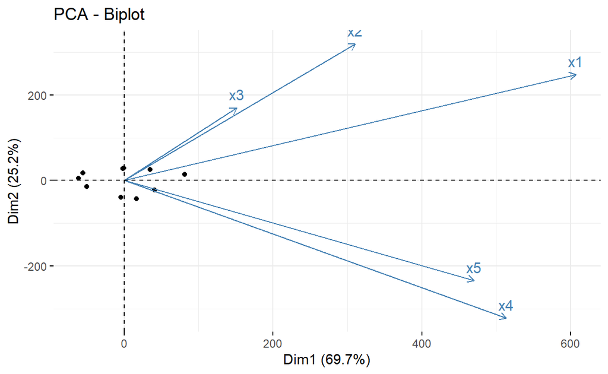

```r
# Biplot
fviz_pca_biplot(student.prcomp, label = "var")
```

`Caution!` 주성분 점수와 변수 적재를 하나의 그래프에 함께 표현한 것을 행렬도(Biplot)라고 한다. 위 Biplot에서는 주성분 점수를 점으로 표현하고, 변수 적재를 화살표로 표현한다. Biplot는 다음을 기준으로 해석할 수 있다.  
1. 점은 각 case(데이터셋에서 하나의 행)에 대한 주성분 점수를 나타낸다.  
2. 화살표는 변수 적재값을 의미하며, 정확한 변수 적재값은 알 수 없다.  
3. 화살표의 길이는 상관성의 정도를 표현한다. 즉, 주축을 기준으로 화살표의 길이가 길수록 변수와 해당 주성분은 강한 상관성을 가진다.  
4. 화살표와 주축이 평행에 가까울수록 해당 변수는 해당 주성분에만 큰 영향을 미친다.  
5. 화살표들 간의 각도가 작을수록 해당 변수들은 강한 양의 상관관계를 나타내며, 180도는 강한 음의 상관관계를 나타낸다. 또한, 직각은 상관성이 없음을 의미한다.  
Biplot을 통해서 군집성, 변수들의 상관구조 등을 시각적으로 파악할 수 있다.  
`Result!` Biplot의 x축과 y축은 각각 첫 번째와 두 번째 주성분 점수를 의미한다. 변수 `x1`과 `x4`는 첫 번째 주축(x축, 수평 점선)을 기준으로 화살표의 길이가 길며, 이는 두 변수가 첫 번째 주성분과 강한 상관성을 가진다고 할 수 있다. 또한, 변수 `x1`, `x2`, `x3`의 화살표들 간의 각도가 작기 때문에(즉, 서로 가까이 위치해있기 때문에) 강한 양의 상관관계를 가지며, 변수 `x4`와 `x5` 또한 강한 양의 상관관계를 가진다.

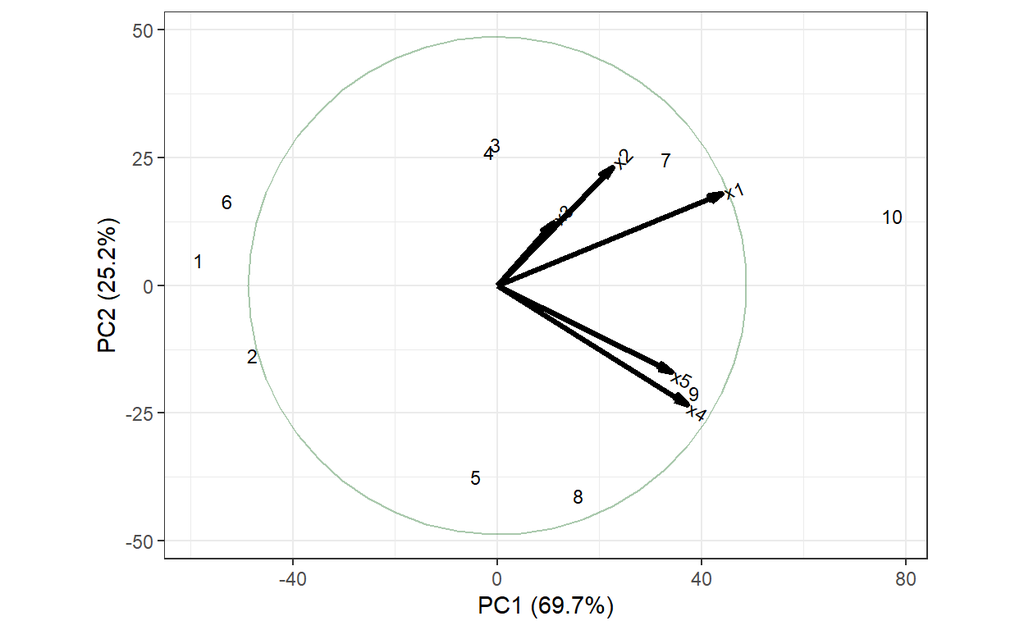

```r
# ggbiplot을 이용한 Biplot
ggbiplot(student.prcomp,                               # 함수 prcomp에 의한 객체
         obs.scale = 1,                                # 관찰값에 적용할 스케일
         var.scale = 1,                                # 변수에 적용할 스케일
         labels = student$ID,                          # 점에 대한 라벨
         circle = TRUE) +
  theme_bw()
```

`Caution!` Package `"ggbiplot"`에서 제공하는 함수 `ggbiplot()`를 이용하여 Biplot을 만들 수 있으며, 함수에 대한 자세한 옵션은 [여기](https://www.rdocumentation.org/packages/ggbiplot/versions/0.55/topics/ggbiplot)를 참고한다.

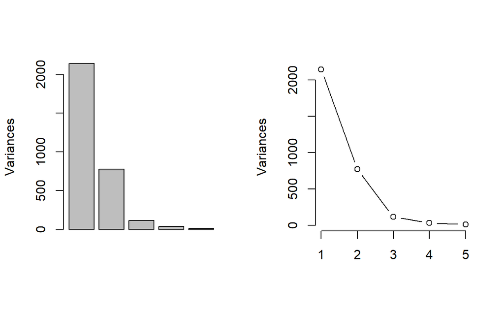

```r
# 스크리 그래프 Ver.1 (y축 : 고유값)
par(mfrow = c(1, 2))
screeplot(student.prcomp, type = "b", main = "")        # 막대그래프
screeplot(student.prcomp, type = "l", main = "")        # 선 그래프
```

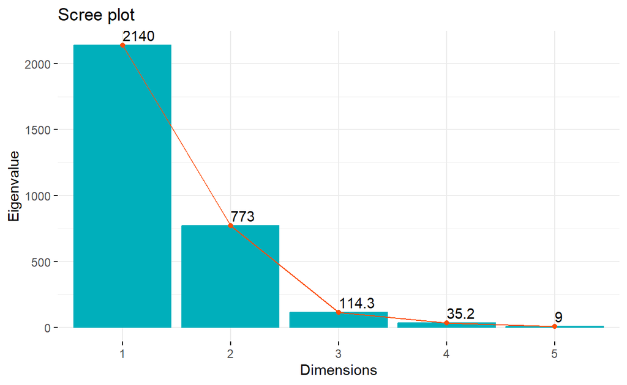

```r
# 스크리 그래프 Ver.2
fviz_screeplot(student.prcomp,
               addlabels = TRUE,                       # 막대 높이 표시 여부
               # geom = "line",                        # 그래프 유형(bar / line)
               choice = "eigenvalue",                  # y축 (variance / eigenvalue)
               linecolor = "#FC4E07",                  # 선 색깔
               barcolor = "#00AFBB",                   # 막대의 윤곽선 색깔
               barfill = "#00AFBB")                    # 막대의 색깔
```

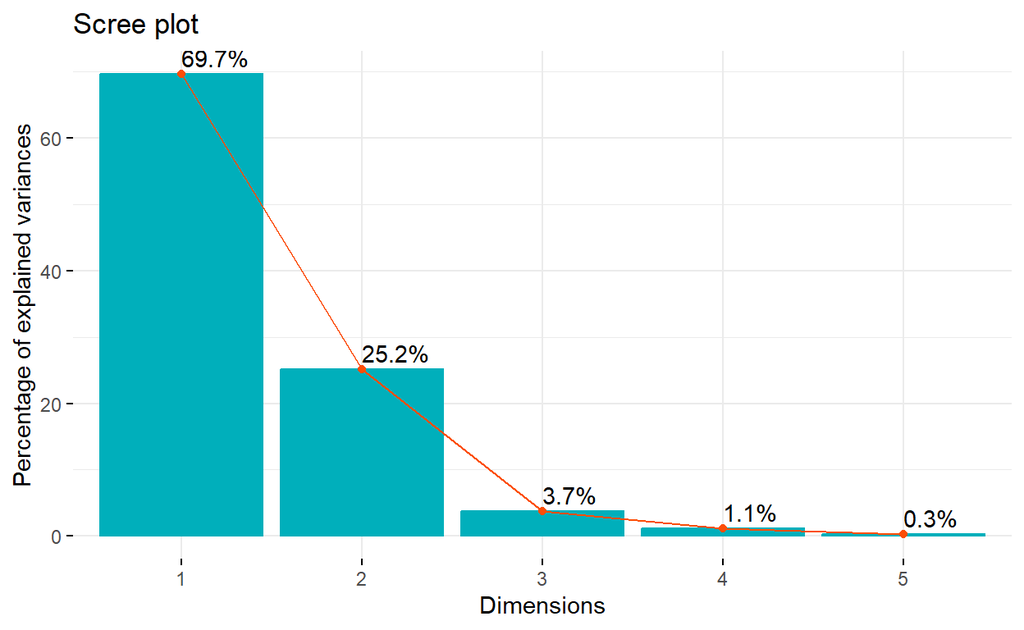

```r
fviz_screeplot(student.prcomp,
               addlabels = TRUE,                       # 막대 높이 표시 여부
               choice = "variance",                    # y축(variance / eigenvalue)
               linecolor = "#FC4E07",                  # 선 색깔
               barcolor = "#00AFBB",                   # 막대의 윤곽선 색깔
               barfill = "#00AFBB")                    # 막대의 색깔
```

`Result!` 스크리 그래프를 보면 첫 번째 주성분과 두 번째 주성분의 분산(고유값)이 크며 가파른 경사를 형성한다. 그러므로, 2개의 주성분 개수를 고려할 수 있다.

## **4. 상관행렬을 이용한 주성분분석**

```r
student.cor.prcomp <- prcomp(student[,c("x1", "x2", "x3", "x4", "x5")], center = TRUE, scale = TRUE)
student.cor.prcomp
```

```
Standard deviations (1, .., p=5):
[1] 1.7852209 1.2132058 0.4662250 0.3308475 0.1195505

Rotation (n x k) = (5 x 5):
         PC1         PC2         PC3        PC4         PC5
x1 0.5175853  0.09386107 -0.71009530  0.4642922  0.05910103
x2 0.4516210  0.43816660 -0.11258435 -0.7683317  0.03224429
x3 0.4206036  0.47398415  0.62887267  0.4183725 -0.16707843
x4 0.3980188 -0.57412032  0.06907097 -0.1329413 -0.69965898
x5 0.4391100 -0.49489900  0.28781556 -0.0372845  0.69139676
```

`Caution!` 상관행렬에 기초하여 주성분분석을 수행한다는 것은 표준화된 변수를 이용하여 주성분분석을 수행한다는 것을 의미한다. 함수 `prcomp()`의 옵션 `center = TRUE`와 `scale = TRUE`를 지정하여 변수를 표준화한 후, 상관행렬에 기초한 주성분분석을 수행할 수 있다.  
`Result!` 상관행렬을 이용한 주성분분석 결과는 위에서 공분산행렬에 기초하여 수행한 주성분분석 결과와는 다른 것을 확인할 수 있다.

```r
student.cor.prcomp$sdev        # 주성분의 표준편차
```

```
[1] 1.7852209 1.2132058 0.4662250 0.3308475 0.1195505
```

```r
student.cor.prcomp$sdev^2      # 주성분의 분산 = 주성분에 의해 설명되는 분산의 양 = 상관행렬의 고유값
```

```
[1] 3.18701362 1.47186824 0.21736574 0.10946007 0.01429233
```

`Caution!` 주성분의 분산은 함수 `eigen(cor(student[,c("x1", "x2", "x3", "x4", "x5")]))`를 통해 얻어진 상관행렬의 고유값과 동일하며, 상관행렬의 대각성분 합이 주성분 분산의 합(상관행렬의 고유값의 합)인 변수 개수 “5”와 같음을 알 수 있다.

```r
student.cor.prcomp$rotation    # 주축의 계수
```

```
         PC1         PC2         PC3        PC4         PC5
x1 0.5175853  0.09386107 -0.71009530  0.4642922  0.05910103
x2 0.4516210  0.43816660 -0.11258435 -0.7683317  0.03224429
x3 0.4206036  0.47398415  0.62887267  0.4183725 -0.16707843
x4 0.3980188 -0.57412032  0.06907097 -0.1329413 -0.69965898
x5 0.4391100 -0.49489900  0.28781556 -0.0372845  0.69139676
```

`Caution!` 주축의 계수는 함수 `eigen(cor(student[,c("x1", "x2", "x3", "x4", "x5")]))`를 통해 얻어진 상관행렬의 단위 고유벡터와 동일하다.  
`Result!` 첫 번째 주성분은 $Y_1=0.518Z_{1}+0.452Z_{2}+0.421Z_{3}+0.398Z_{4}+0.439Z_{5}$이며, 두 번째 주성분은 $Y_2=0.094Z_{1}+0.438Z_{2}+0.474Z_{3}-0.574Z_{4}-0.495Z_{5}$이 된다. 여기서 확률변수 $Z_{i}$는 $(X_i-\mu_i)/\sigma_{i}$이며, $\mu_i$와 $\sigma_{i}$는 각각 $X_i$의 평균과 표준편차를 의미한다. 또한, 변수 `x1`-`x5`는 $X_1$-$X_5$로 표현한다.  
주성분의 의미를 해석해보면, 첫 번째 주성분은 계수가 서로 비슷하므로 전반적인 평점을 나타낸다고 할 수 있으며, 두 번째 주성분은 변수 `x1-x3`와 변수 `x4-x5`의 부호가 반대이므로 국어, 영어, 제2외국어의 “인문계열”과 수학, 과학의 “이과계열”의 점수 차이를 나타낸다고 할 수 있다.

```r
# 요약
summary(student.cor.prcomp)
```

```
Importance of components:
                          PC1    PC2     PC3     PC4     PC5
Standard deviation     1.7852 1.2132 0.46622 0.33085 0.11955
Proportion of Variance 0.6374 0.2944 0.04347 0.02189 0.00286
Cumulative Proportion  0.6374 0.9318 0.97525 0.99714 1.00000
```

`Result!` 처음 2개의 고유값은 3.187(= $1.7852^2$), 1.472(= $1.2132^2$)로서 각각 전체 변동의 63.7%(= 3.187/5)와 29.4%(= 1.472/5)를 차지한다. 따라서, 처음 2개의 주성분에 의해 데이터 변동의 약 93.2%가 설명될 수 있음을 알 수 있다. 이는 2개의 주성분만으로 데이터 변동을 충분히 설명할 수 있음을 의미한다. 만약 처음 2개의 주성분을 새로운 변수로 고려할 경우, 이는 원래 다섯 개의 예측변수들이 가지고 있는 정보를 2차원으로 축소한다는 의미를 가진다.

```r
# 변수 적재 Ver.1
1:5 %>%                                                # 첫 번째 변수부터 다섯 번째 변수에 function을 적용
  map_df(function(x) student.cor.prcomp$rotation[,x]*student.cor.prcomp$sdev[x])
```

```
# A tibble: 5 × 5
        x1       x2      x3      x4      x5
     <dbl>    <dbl>   <dbl>   <dbl>   <dbl>
1  0.924    0.806    0.751   0.711   0.784
2  0.114    0.532    0.575  -0.697  -0.600
3 -0.331   -0.0525   0.293   0.0322  0.134
4  0.154   -0.254    0.138  -0.0440 -0.0123
5  0.00707  0.00385 -0.0200 -0.0836  0.0827
```

`Caution!` 주성분의 변수 적재(Variable Loading)는 단위 고유벡터(= 주축의 계수)와 고유값의 제곱근(= 주성분의 표준편차)을 곱함으로써 계산될 수 있다. 변수 적재를 계산하기 위해 함수 `map_df()`를 이용한다.  
`Result!` 변수 적재는 각 변수가 특정 주성분에 얼마나 기여하는지를 설명한다. 결과값의 부호는 양/음의 상관관계를 나타내며, 값의 절대값이 클수록 주성분과 변수는 강한 관계를 가지고 있다. 출력 결과는 피어슨 상관계수처럼 해석할 수 있다. 예를 들어, 변수 `x1`은 첫 번째 주성분과 강한 양의 상관성($r=0.924$)을 가지고 있으며, 변수 `x4`는 두 번째 주성분과 강한 음의 상관성($r=-0.697$)을 가지고 있다.

```r
# 변수 적재 Ver.2
pcaDat <- get_pca(student.cor.prcomp)                  # 주성분 결과에서 변수에 대한 정보(좌표, 제곱 코사인, 기여) 추출
round(pcaDat$coord,3)                                  # 변수 적재
```

```
   Dim.1  Dim.2  Dim.3  Dim.4  Dim.5
x1 0.924  0.114 -0.331  0.154  0.007
x2 0.806  0.532 -0.052 -0.254  0.004
x3 0.751  0.575  0.293  0.138 -0.020
x4 0.711 -0.697  0.032 -0.044 -0.084
x5 0.784 -0.600  0.134 -0.012  0.083
```

`Caution!` 변수 적재는 package `"factoextra"`에서 제공하는 함수 `get_pca()`를 이용하여 계산할 수 있다.

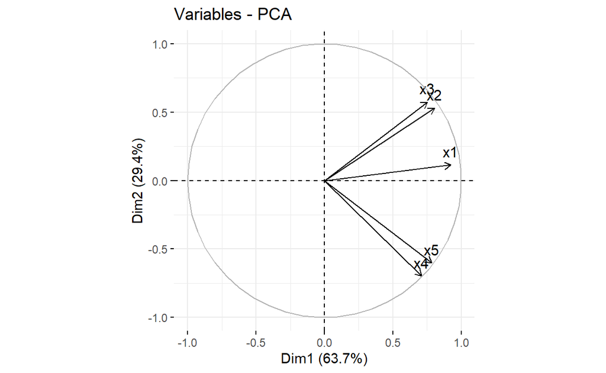

```r
# 변수 적재 그래프
fviz_pca_var(student.cor.prcomp)
```

`Result!` 그래프의 x축과 y축은 각각 첫 번째 주성분과 두 번째 주성분에 대한 변수 적재값을 의미하며, 특정 주축을 기준으로 화살표의 길이가 길수록 해당 변수와 해당 주성분은 강한 상관성을 가진다.

```r
# 주성분 점수
student.cor.score <- student.cor.prcomp$x
student.cor.score
```

```
             PC1         PC2         PC3         PC4         PC5
 [1,] -2.2470840  0.59291807  0.11734892  0.57000378  0.07050020
 [2,] -2.3648070 -0.56384142 -0.43800069  0.09637971 -0.01316672
 [3,]  0.6371219  1.45367994  0.36829470 -0.24073999 -0.01752385
 [4,]  0.4119368  1.24346894  0.04275167 -0.44523585 -0.01646831
 [5,] -0.9778549 -1.92149789 -0.49632909 -0.44545382 -0.01505308
 [6,] -1.7773223  1.14510117  0.12617138 -0.03003567 -0.10059295
 [7,]  1.4790506  0.68283716 -0.45563359 -0.05657281  0.17677268
 [8,]  0.4475007 -1.57666392  0.88207761 -0.01920990  0.16749550
 [9,]  1.3831919 -0.97790554  0.34768523  0.16519787 -0.22970590
[10,]  3.0082663 -0.07809652 -0.49436614  0.40566668 -0.02225757
```

`Caution!` 주성분 점수는 각 case의 관측값을 주성분에 대입함으로써 얻을 수 있으며, 고차원의 원본 데이터셋 대신 차원이 축소된 데이터셋으로 유용하게 사용될 수 있다. 함수 `prcomp()`를 이용한 결과 `student.cor.prcomp`에는 주성분 점수가 포함되어 있다.
`Result!` 첫 번째 주성분과 두 번째 주성분에 의해 얻어지는 $i$번째 case의 주성분 점수는 다음의 식을 이용하여 얻을 수 있다.
$$\begin{align}
\begin{cases}
y_{i1}=0.518z_{i1}+0.452z_{i2}+0.421z_{i3}+0.398z_{i4}+0.439z_{i5},\\
y_{i2}=0.094z_{i1}+0.438z_{i2}+0.474z_{i3}-0.574z_{i4}-0.495z_{i5},
\end{cases}
\end{align}$$
여기서 $z_{ij}=(x_{ij}-\bar{x}_{j})/s_{j}$는 $i$번째 case의 $j$번째 변수 관찰값 $x_{ij}$에서 $j$번째 변수의 평균값 $\bar{x}_j$을 뺀 후 $j$번째 변수의 표준편차 값 $s_j$로 나눈 것을 의미한다.

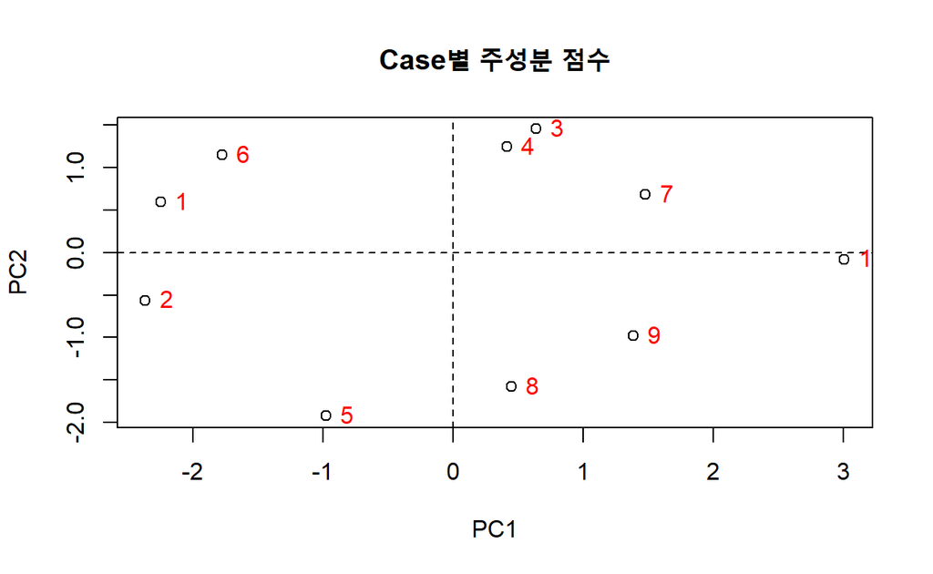

```r
# 주성분 점수 그래프 Ver.1
plot(student.cor.score[,1:2],
     main = "Case별 주성분 점수")
abline(v = 0, h = 0, lty = 2)
text(student.cor.score[,1:2],  labels = student$ID, pos = 4, col = "red")
```

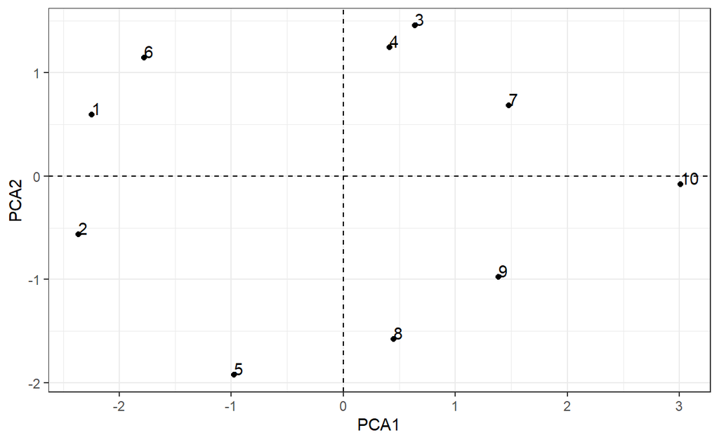

```r
# 주성분 점수 그래프 Ver.2
studentPca <- student %>%
  mutate(PCA1 = student.cor.score[, 1], PCA2 = student.cor.score[, 2])
ggplot(studentPca, aes(PCA1, PCA2)) +
  geom_point() +
  geom_hline(yintercept=0, linetype='dashed', color='black') +
  geom_vline(xintercept=0, linetype='dashed', color='black') +
  geom_text(aes(label = ID), hjust=0, vjust=0) +
  theme_bw()
```

`Result!` 그래프의 수직선을 중심으로 오른쪽에 위치하는 점들은 첫 번째 주성분 점수가 높다는 것을 의미하고 왼쪽에 위치하는 점들은 첫 번째 주성분 점수가 낮다는 것을 의미한다. 그래프를 살펴보면, 그래프의 오른쪽에 위치하는 “10”, “9”, “7”번 case는 첫 번째 주성분 값이 높으며, 이는 “10”, “9”, “7”번 case의 전반적인 평점이 높다고 해석할 수 있다. 반면, 왼쪽에 위치하는 “1”, “2”, “6”번 case는 전반적인 평점이 낮다고 해석할 수 있다. 마찬가지로 수평선을 중심으로 위쪽에 위치하는 점들은 두 번째 주성분 점수가 높다는 것을 의미하고 아래쪽에 위치하는 점들은 두 번째 주성분 점수가 낮다는 것을 의미한다. 두 번째 주성분 점수가 높다는 것은 국어, 영어, 제2외국어 등 인문계열 과목에 대해서는 점수가 높으나 수학, 과학 등 이과계열 과목에 대해서는 점수가 낮다고 해석할 수 있다.

```r
# 주성분 점수 예측
predict(student.cor.prcomp, newdata = tail(student[,c("x1", "x2", "x3", "x4", "x5")], 2))
```

```
        PC1         PC2        PC3       PC4         PC5
9  1.383192 -0.97790554  0.3476852 0.1651979 -0.22970590
10 3.008266 -0.07809652 -0.4943661 0.4056667 -0.02225757
```

`Caution!` 함수 `predict()`를 이용하여 새로운 case에 대한 주성분 점수를 예측할 수 있다. 여기서는 설명의 편의상 마지막 2개의 case를 새로운 자료로 취급하여 예측을 수행하였다.

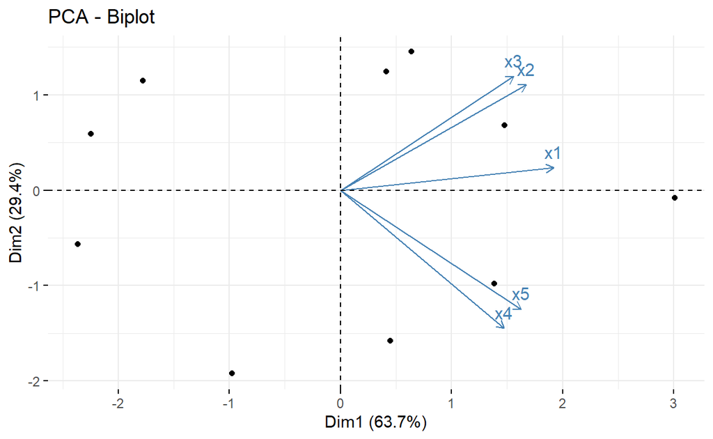

```r
# Biplot
fviz_pca_biplot(student.cor.prcomp, label = "var")
```

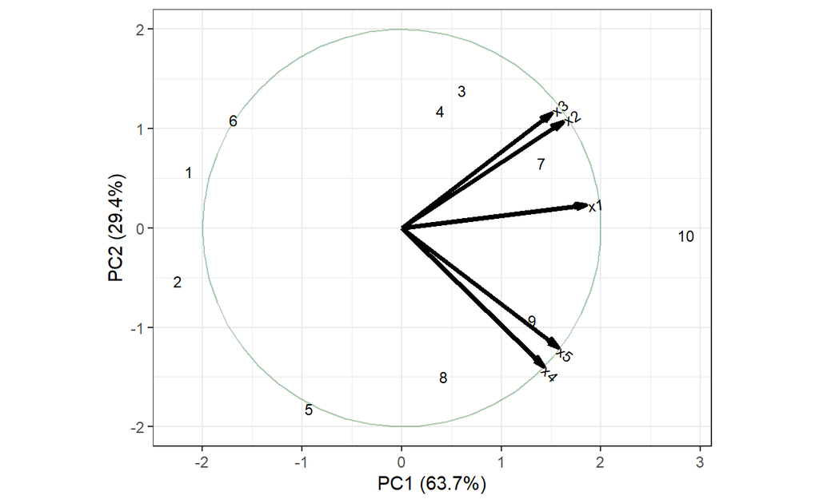

```r
# ggbiplot을 이용한 Biplot
ggbiplot(student.cor.prcomp,                           # 함수 prcomp에 의한 객체
         obs.scale = 1,                                # 관찰값에 적용할 스케일
         var.scale = 1,                                # 변수에 적용할 스케일
         labels = student$ID,                          # 점에 대한 라벨
         circle = TRUE) +
  theme_bw()
```

`Caution!` Package `"ggbiplot"`에서 제공하는 함수 `ggbiplot()`를 이용하여 Biplot을 만들 수 있으며, 함수에 대한 자세한 옵션은 [여기](https://www.rdocumentation.org/packages/ggbiplot/versions/0.55/topics/ggbiplot)를 참고한다.

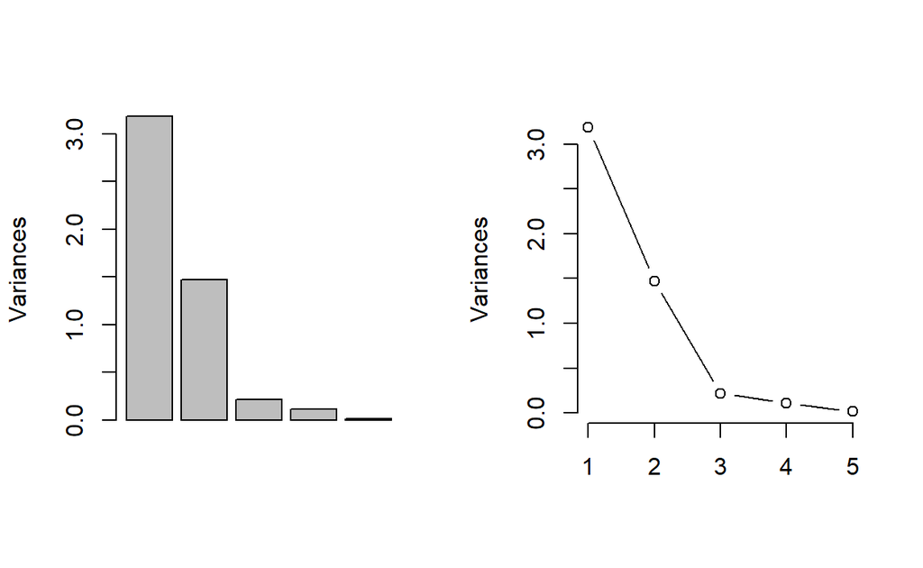

```r
# 스크리 그래프 Ver.1 (y축 : 고유값)
par(mfrow = c(1, 2))
screeplot(student.cor.prcomp, type = "b", main = "")   # 막대그래프
screeplot(student.cor.prcomp, type = "l", main = "")   # 선 그래프
```